# Kostenoffenlegung als Wettbewerbsvorteil

Chancen und Potenziale der Kostentransparenz

# Motivation

Die Untersuchung von Kostentransparenz ist aus ökonomischer Sicht besonders spannend, da sie Einblicke in das Zusammenspiel von Marktverhalten, Preiswahrnehmung und Konsumentenvertrauen ermöglicht. In klassischen Märkten gilt Information als asymmetrisch verteilt - insbesondere Kostenstrukturen bleiben für Konsument:innen meist verborgen. Wenn Unternehmen jedoch freiwillig ihre Produktionskosten offenlegen, entsteht eine neue Form der Marktkommunikation, die sowohl auf das Kaufverhalten als auch auf die Markenbindung Einfluss nehmen kann.

In diesem Projekt beschäftigen Sie sich mit der ökonomischen Wirkung unterschiedlicher Formen von Kostentransparenz, darunter produktbezogene Einzelkosten-Offenlegung im Point-of-Sale oder auch verbal vermittelte Transparenz in Kombination mit Vertrauensmessung. Ziel ist es, zu untersuchen, wie sich diese Varianten auf Zahlungsbereitschaft, Vertrauen und wahrgenommene Preisfairness auswirken.

Kern dieser Ausarbeitung ist die Frage, inwiefern Kostentransparenz eine rationale Kaufentscheidung unterstützt oder über emotionale Mechanismen - etwa durch erhöhte Markenattraktivität - wirkt. Für die Analyse greifen Sie auf ein breites Methodenrepertoire zurück, das ökonomische Modellierung mit experimenteller Verhaltensforschung verbindet, und leisten so einen Beitrag zum besseren Verständnis moderner Konsumentenentscheidungen in transparenten Märkten. Für ihre Analyse verwenden Sie die Daten der folgenden Ausarbeitung:

**Mohan, B., Buell, R. W., & John, L. K. (2020). Lifting the veil: The benefits of cost transparency. Marketing Science, 39(6), 1105-1121.**

# Aufbau der Studie

1. Lesen Sie sich den folgenden Text zum Hintergrund und Aufbau der Studie durch und beantworten Sie nachfolgende Fragen dazu:

Der Ausgangspunkt der betrachteten Untersuchung war ein reales Ereignis: Ein Online-Händler stellte im Dezember 2013 ein hochwertiges Lederportemonnaie zum Verkauf. Einige Wochen später wurde auf den Produktseiten eine Infografik zur Kostenzusammensetzung ergänzt, allerdings versehentlich nur bei drei von fünf Farbvarianten. Obwohl der Händler diesen Fehler nicht beabsichtigte, entstand daraus ein sogenanntes natürliches Experiment, also eine reale Vergleichssituation mit kontrollierbaren Unterschieden. Die Verkäufe konnten analysiert werden, um zu überprüfen, ob die Offenlegung der Produktionskosten einen Einfluss auf das Kaufverhalten hatte.

Dieses natürliche Experiment lieferte erste Hinweise darauf, dass Kostentransparenz wirkt - und war damit die Basis für zwei gezielte Experimente im Labor, die Sie sich in diesem Projekt genauer anschauen sollen. Beide Laborexperimente knüpfen an die reale Ausgangslage an - gehen aber unterschiedliche Forschungsfragen an:

Experiment 1: In einem realitätsnahen Online-Setting wurde untersucht, ob Konsument:innen anders entscheiden, wenn sie Informationen zu Produktionskosten sehen. Hierbei sahen die Teilnehmer:innen eine Produktseite für einen Rucksack von Everlane - entweder mit oder ohne Kostenaufstellung (vgl. Abbildung 1: Kostentransparenz Infografik im Anhang). Zusätzlich wurde ein Vergleichsprodukt von J. Crew gezeigt (ohne Hinweise zur Kostenzusammensetzung). Die Teilnehmer:innen mussten entscheiden, von welchem Anbieter sie lieber einen Gutschein erhalten würden. Das Ziel der Forscher war es zu messen, ob Konsument:innen bei mehr Transparenz auch eher kaufen, folglich sich für diesen Gutschein entscheiden.

Experiment 2: Nachdem Experiment 1 zeigte, dass es einen Effekt der Kostentransparenz gibt, stellt sich die psychologische Anschlussfrage, warum es diesen Effekt gibt und wie dieser festzumachen ist. So sahen die Teilnehmer:innen im 2. Experiment ein fiktives Produkt - eine Schokoladentafel. In der Kontrollgruppe wurden nur übliche Produktinfos gezeigt. In der Treatmentgruppe gab es zusätzlich eine detaillierte Kostenaufstellung (vgl. Abbildung 2: Design der Schokoladenverpackung ohne und mit Kostentransparenz im Anhang). Im Anschluss wurden Vertrauen in die Marke und Kaufbereitschaft durch einen Fragebogen abgefragt. So sollte herausgefunden werden, ob Vertrauen der zentrale psychologische Mechanismus für die Kaufentscheidung der Kund:innen ist.

Beantworten Sie nun folgende Fragen:

1. Welches reale Ereignis war der Auslöser der Forschung?
2. Welche konkrete Verhaltensfrage steht im Mittelpunkt von Experiment 1 - Was wollten die Forscher:innen direkt am Kaufverhalten testen?
3. Welcher psychologische Faktor steht im Zentrum von Experiment 2 - und wie hängt er mit dem Kaufverhalten zusammen?
1. Der Auslöser der Forschung war ein reales Ereignis bei einem Online-Händler im Dezember 2013. Ein hochwertiges Lederportemonnaie wurde zum Verkauf angeboten. Einige Wochen später wurde auf den Produktseiten versehentlich nur bei drei von fünf Farbvarianten eine Infografik zur Kostenzusammensetzung ergänzt. Dieser unbeabsichtigte Fehler führte zu einem sogenannten natürlichen Experiment, das es ermöglichte, den Einfluss von Kostentransparenz auf das Kaufverhalten real zu untersuchen.
2. Im Mittelpunkt von Experiment 1 steht die konkrete Verhaltensfrage, ob Konsument:innen ihr Kaufverhalten ändern, wenn sie Informationen zu den Produktionskosten eines Produkts erhalten. Die Forscher:innen wollten direkt testen, ob die Offenlegung der Kosten (Kostentransparenz) dazu führt, dass sich mehr Teilnehmer:innen für das Produkt mit transparenter Kostenaufstellung entscheiden – in diesem Fall, ob sie lieber einen Gutschein für den Anbieter mit Kostentransparenz (Everlane) wählen als für einen Anbieter ohne diese Information (J. Crew).
3. Im Zentrum von Experiment 2 steht der psychologische Faktor “Vertrauen in die Marke”. Die Forscher:innen wollten herausfinden, ob die erhöhte Kostentransparenz das Vertrauen der Konsument:innen in die Marke steigert und ob dieses Vertrauen wiederum die Kaufbereitschaft positiv beeinflusst. Das heißt: Es wurde untersucht, ob Transparenz nicht nur direkt das Kaufverhalten beeinflusst, sondern ob dies vor allem deshalb geschieht, weil Konsument:innen der Marke mehr vertrauen, wenn sie offen über ihre Kosten informiert werden.

Nachdem Sie nun die grundlegende Forschungsidee und Zielsetzung der beiden Experimente kennengelernt haben, befassen wir uns im nächsten Schritt vertiefend mit Experiment 1. Ziel ist es, den genauen Aufbau, sowie das konkrete Verhalten der Teilnehmer:innen besser zu verstehen.

2. Lesen Sie sich den folgenden Text zum Aufbau des ersten Experiments durch und beantworten Sie anschließend Fragen dazu:

Cost transparency refers to the disclosure of the costs to produce a good or provide a service. Although cost transparency is a strategy traditionally employed in the context of supplier-firm relationships, wherein the two-way sharing of cost information between parties facilitates collaboration on cost reduction measures, we investigate its effects within the context of consumer-firm relationships. Information on the costs associated with providing goods and services is rarely shared with consumers, but we provide evidence of when and why voluntarily doing so can increase consumers’ purchase interest. Specifically, building on the psychology of disclosure and trust, we posit that cost transparency, insofar as it represents an act of intimate disclosure, fosters trust. In turn, we propose that this heightened trust increases consumers’ willingness to purchase from the transparent firm. In the sections that follow, we discuss our central predictions and highlight alternative accounts. Then, we present experiments, conducted in the lab and in the field, that document the main effects of cost transparency, its underlying psychological drivers, and conditions that moderate its effects.

This first experiment explores how cost transparency influences consumer preferences in an online shopping context. The study was designed as a between-subjects randomized experiment using an incentive-compatible setup, meaning participants made real choices with the possibility of receiving a tangible reward. A total of 509 U.S.-based participants were recruited through Amazon Mechanical Turk (MTurk). Each participant was randomly assigned to one of two experimental conditions:

- Cost Transparency Condition: Participants were shown a simulated product page for a backpack sold by the retailer Everlane. This page included a cost breakdown infographic, listing the production costs such as materials, labor, transport, and duties, with a clearly stated total cost.
- Control Condition: Participants saw the same backpack from Everlane but without any cost information. In both conditions, participants also saw a comparable backpack from J. Crew, which does not practice cost transparency.

Participants were instructed to view both product pages and then asked which company they would prefer to receive a $50 gift card from. Their response served as the main behavioral outcome, representing a choice between the transparent vs. non-transparent retailer. To ensure accurate interpretation of the presented information, a comprehension check followed the main choice question. Participants were also asked for demographic information such as age, gender, income, and education, to allow for potential control variables in later analysis.

Beantworten Sie nun folgende Fragen:

1. Wie viele Personen nahmen final an dem Experiment teil?
2. Worin bestand der Unterschied zwischen der Transparenzbedingung und der Kontrollbedingung?
3. Welche Anreizstruktur wurde verwendet, um die Entscheidung der Teilnehmenden realistisch zu gestalten?
4. Wie unterschieden sich die beiden gezeigten Onlinehändler im Experiment?
5. Warum wurde im Anschluss an die Entscheidungsfrage ein Verständnischeck durchgeführt?
6. In der Beschreibung des Experiments wird von “between-subjects randomized experiment using an incentive-compatible setup” gesprochen. Was versteht man hierunter im Detail?

*Hinweis:* Für die Beantwortung der letzten Frage können Sie [diesen Artikel (Seite 1-5)](https://www.researchgate.net/publication/268269783_Incentives_in_Experiments_A_Theoretical_Analysis) als Grundlage verwenden.

1. An dem Expiriment nahmen insgesamt 509 US-amerikanische Personen teil.
2. In der Transparenzbedingung wurde den Teilnehmenden ein Produktseite eines Rucksacks von Everlane gezeigt, die zusätzlich eine grafische Aufschlüsselung der Produktionskosten (z.B. Material, Arbeit, Transport, Abgaben) enthielt. In der Kontrollbedingung sahen die Teilnehmenden dieselbe Produktseite, jedoch ohne jegliche Kosteninformationen.
3. Die Anreizstruktur bestand darin, dass die Teilnehmer reale Entscheidungen treffen mussten, mit der Möglichkeit, eine 50-Dollar-Geschenkkarte zu erhalten. Dies machte die Entscheidung für die Teilnehmer realistisch und anreizkompatibel.
4. Beide Gruppen sahen zwei Produktseiten: einen Rucksack von Everlane (mit oder ohne Kostentransparenz je nach Bedingung) und einen vergleichbaren Rucksack von J. Crew, einem Händler, der keine Kostentransparenz bietet. Der Unterschied bestand also darin, dass nur Everlane potenziell transparente Informationen zeigte, während J. Crew stets als nicht-transparenter Anbieter diente.
5. Der Verständnischeck wurde durchgeführt, um sicherzustellen, dass die Teilnehmer die präsentierten Informationen korrekt interpretiert haben. Dies ist wichtig für die Validität der Ergebnisse.
6. Ein between-subjects randomized experiment bedeutet, dass jede Versuchsperson zufällig nur einer von mehreren Bedingungen zugewiesen wird (hier: Transparenzbedingung oder Kontrollbedingung), sodass keine Person beide Bedingungen erlebt. Dadurch werden Übertragungseffekte zwischen den Bedingungen verhindert. Ein incentive-compatible setup bedeutet, dass die Entscheidungssituation so gestaltet ist, dass die Teilnehmenden einen echten Anreiz haben, ihre wahren Präferenzen offenzulegen. Das wird durch materielle Belohnungen (wie hier der $50-Geschenkgutschein) erreicht. Theoretisch betrachtet, wie es der angegebene Artikel beschreibt, erhöhen solche Anreize die Zuverlässigkeit und Aussagekraft experimenteller Daten, da die Teilnehmenden nicht „bloß hypothetisch“, sondern realistisch und eigennützig motiviert entscheiden.

# Daten

## Datenimport und -aufbereitung

Die Daten, die Sie für die nachfolgenden Analysen verwenden, wurden zu Replikationszwecken von den Autoren der Studie zur Verfügung gestellt und können hier heruntergeladen werden:

**Bhavya Mohan, Ryan W. Buell, Leslie K. John (2020) Lifting the Veil: The Benefits of Cost Transparency. Marketing Science 39(6):1105-1121. mksc.2019.1200.sm1.pdf**

Wir haben die Daten für Sie heruntergeladen und im Unterordner mit dem Namen `Daten` bereitgestellt. Für ihre Analyse werden die Dateien `Experiment1.csv` und `Experiment2.csv` genutzt. Für die Zusatzaufgabe ist die Datei `Experiment3.csv` relevant.

3. Lesen Sie den Datensatz `Experiment1.csv` aus dem Unterordner `Daten` in R ein. Nennen Sie den Datensatz in R `daten_exp1`.

Im Datensatz sind unterschiedliche Variablen enthalten. Weiterhin habe wir Ihnen ein Readme mit den Beschreibungen zu den Variablen bereitgestellt. Nutzen Sie dieses und den Text aus Aufgabe 2, um die Variablen zu beschreiben.

Im Datensatz zu Experiment 1 sind verschiedene Variablen enthalten, die sowohl experimentelle Bedingungen als auch demografische Merkmale und Verhaltensmaße der Teilnehmenden erfassen.

Die Variable `treatment` gibt an, ob die Teilnehmenden der Kosten-Transparenz-Bedingung zugeordnet wurden (1 = Kosten-Transparenz, 0 = Kontrollbedingung ohne Kosteninformation). Sie dient dazu, die Wirkung der Transparenz auf das Entscheidungsverhalten zu untersuchen. In der Transparenzbedingung sahen die Teilnehmenden eine Produktseite mit einer grafischen Aufschlüsselung der Herstellungskosten des Produkts, während diese Information in der Kontrollbedingung fehlte.

Die Variable `everlane` erfasst die Wahl der Geschenkkarte durch die Teilnehmenden. Ein Wert von 1 bedeutet, dass die Everlane-Geschenkkarte gewählt wurde (das Unternehmen, das Kosten-Transparenz zeigte), während ein Wert von 0 die Wahl der J Crew-Geschenkkarte (ohne Kosten-Transparenz) anzeigt. Dies ist die zentrale abhängige Variable des Experiments.

Mit der Variable `passed` wird dokumentiert, ob eine Versuchsperson den Verständnischeck am Ende des Experiments bestanden hat (Wert = 1) oder nicht (Wert = 0). Diese Prüfung soll sicherstellen, dass die Entscheidung auf einer korrekten Wahrnehmung der experimentellen Informationen beruht.

Die Variable `email_provided` zeigt an, ob Teilnehmende freiwillig ihre E-Mail-Adresse angegeben haben (Wert = 1) oder nicht (Wert = 0). Dies diente dazu, im Fall eines Gewinns den Gutschein zustellen zu können, und kann zudem als Indikator für die Ernsthaftigkeit der Teilnahme interpretiert werden.

Unter anderem wurde die Variable `female` festgehalten. Sie gibt das Geschlecht der Teilnehmenden an, sofern dieses freiwillig angegeben wurde (1 = weiblich, 0 = männlich).

Das `Alter` der Teilnehmenden wurde offen erfasst und ist als numerische Variable gespeichert.

Der Bildungsstand wurde in der Variable `educ` auf einer ordinalen Skala von 1 bis 5 angegeben, wobei 1 für „einige Jahre Schule“ und 5 für „postgraduale oder berufliche Ausbildung“ steht. Diese Variable ermöglicht Aussagen über mögliche Bildungsunterschiede im Entscheidungsverhalten.

Schließlich beschreibt die Variable `income` das monatliche Einkommen der Teilnehmenden auf einer Skala von 1 bis 12. Die Skala reicht von „kein Einkommen“ (1) bis „über 10.000 Dollar“ (11), wobei der Wert 12 für „weiß nicht / bevorzuge keine Antwort“ steht. Diese Variable erlaubt eine Analyse der potenziellen Rolle des sozioökonomischen Hintergrunds bei der Bewertung von Kostentransparenz.

## Deskriptive Analyse

Sie sollten sich im ersten Schritt einen Überblick über ihre Daten verschaffen.

4. Auf Basis des Datensatzes `daten_exp1` aus Aufgabe 3 erstellen Sie eine deskriptive Tabelle mit der Anzahl an Beobachtungen, den Mittelwerten, der Standardabweichungen, dem Median, sowie den Minima und Maxima für alle in `daten_exp1` enthaltenen Variablen.

Beschreiben und interpretieren Sie ihre Tabelle. Gehen Sie insbesondere auf die Verteilungen der einzelnen Variablen ein. Was fällt hier besonders auf?

Deskriptive Statistiken der Variablen aus dem Datensatz des Experiments`

|  | Beobachtungen | Mittelwert | Standardabweichung | Median | Minimum | Maximum |
| --- | --- | --- | --- | --- | --- | --- |
| Behandlung | 509 | 0.50 | 0.50 | 0 | 0 | 1 |
| Everlane-Geschenkkarte | 509 | 0.63 | 0.48 | 1 | 0 | 1 |
| Verständnischeck bestanden | 509 | 0.77 | 0.42 | 1 | 0 | 1 |
| E-Mail angegeben | 509 | 0.56 | 0.50 | 1 | 0 | 1 |
| Geschlecht | 509 | 0.49 | 0.50 | 0 | 0 | 1 |
| Alter | 505 | 37.59 | 11.74 | 35 | 18 | 81 |
| Bildungsniveau | 505 | 3.76 | 0.84 | 4 | 1 | 5 |
| Einkommen | 505 | 7.58 | 2.43 | 8 | 1 | 12 |

Zur ersten Orientierung wurde eine deskriptive Analyse aller im Datensatz enthaltenen Variablen durchgeführt. Die Tabelle umfasst zentrale Kennwerte wie die Anzahl an Beobachtungen, Mittelwerte, Standardabweichungen, Mediane sowie Minimal- und Maximalwerte. Insgesamt wurden acht Variablen analysiert.

Das Bildungsniveau wurde auf einer Skala von 1 bis 5 gemessen. Mit einem Mittelwert von 3,76 und einem Median von 4 zeigt sich, dass ein Großteil der Stichprobe ein eher hohes Bildungsniveau aufweist. Die relativ geringe Standardabweichung von 0,84 spricht zudem für eine moderate Streuung in dieser Variable. Die Variable „Einkommen“ reicht von 1 bis 12, wobei der Mittelwert bei 7,58 und der Median bei 8 liegt. Auch hier ist die Verteilung relativ ausgeglichen, mit einem leichten Schwerpunkt im oberen mittleren Bereich der Einkommensskala. Die Standardabweichung beträgt 2,43, was auf eine gewisse Streuung, jedoch keine extremen Ausreißer hinweist.

Zusammenfassend zeigt die deskriptive Analyse eine insgesamt ausgewogene und gut durchmischte Stichprobe. Besonders hervorzuheben ist die hohe Erfolgsquote beim Verständnischeck sowie die breite Altersspanne und das insgesamt hohe Bildungsniveau der Befragten. Die binären Variablen liefern erwartungsgemäß klare Informationen über die Verteilung der jeweiligen Gruppen und legen eine ordnungsgemäße Randomisierung sowie eine ausgewogene Zusammensetzung der Stichprobe nahe.

5. Im Datensatz `daten_exp1` gibt es Variablen für die keine Beobachtungen vorhanden sind.
- Gegeben ihrer Variablenbeschreibung in Aufgabe 3:
  - Macht es Sinn die Beobachtungen aus dem Datensatz zu entfernen, wenn für bestimmte Variablen keine Werte vorhanden sind?
  - Wenn ja, warum?
  - Wie viele Beobachtungen entfernen Sie dadurch aus ihrem Datensatz?

Entfernen Sie nun alle Beobachtungen (d.h. gesamte Zeilen aus dem Datensatz), bei denen für mindestens eine der erhobenen Variablen kein Wert vorliegt, da unvollständige Daten für die Analyse nicht berücksichtigt werden sollen.

Untersuchen Sie weiterhin, ob sich die Teilnehmer, die die Webseite mit der Kostentransparenz gesehen haben (Treatmentgruppe), systematisch von jenen unterscheiden, die die Kontrollversion gesehen haben. Auch wenn es sich um ein Experiment handelt, bei dem die Zuteilung zu den Gruppen zufällig erfolgt ist, sollten Sie dennoch prüfen, ob es unbeabsichtigte (systematische) Unterschiede zwischen den Gruppen gibt. Erstellen Sie hierfür eine Balancing-Tabelle, in der Sie die Mittelwerte von Alter (age), Geschlecht (female), Einkommensstufe (income) und Bildungsniveau (educ) zwischen den beiden Gruppen vergleichen, die Differenzen berechnen und mithilfe von T-Tests prüfen, ob diese Unterschiede statistisch signifikant sind.

- Beschreiben und interpretieren Sie ihre Tabelle.
  - Was fällt Ihnen in Bezug auf die p-Werte auf?
  - Was müssten Sie bei einer weiteren Regressionsanalyse berücksichtigen?

*Hinweis:* Die beiden Gruppen, die Sie in der Balancing Tabelle betrachten sollen, können aus den Werten (1 und 0) der Variable `treatment` abgeleitet werden.

Balancing-Tabelle: Vergleich von Ausgangsmerkmalen zwischen Kontroll- und Treatmentgruppe

| Variable | Kontrollgruppe | Treatmentgruppe | Differenz | p-Wert |
| --- | --- | --- | --- | --- |
| Alter | 37.913 | 37.273 | -0.640 | 0.541 |
| Geschlecht | 0.488 | 0.490 | 0.002 | 0.964 |
| Einkommensstufe | 7.405 | 7.763 | 0.358 | 0.098 |
| Bildungsniveau | 3.734 | 3.794 | 0.060 | 0.418 |

Zunächst wurden alle Beobachtungen aus dem Datensatz entfernt, für die bei mindestens einer der berücksichtigten Variablen (Alter, Geschlecht, Einkommensstufe, Bildungsniveau) Werte fehlten. Dies ist sinnvoll, da unvollständige Beobachtungen die Qualität und Aussagekraft der Analysen beeinträchtigen können. Nur auf Basis vollständiger Daten ist es möglich, Unterschiede zwischen den Gruppen zuverlässig zu bewerten. Beim Entfernen von unvollständigen Zeilen wurden vier Beobachtungen entfernt.

Um zu untersuchen, ob sich die Treatmentgruppe (die die Webseite mit der Kostentransparenz gesehen hat) systematisch von der Kontrollgruppe unterscheidet, wurde eine sogenannte Balancing-Tabelle erstellt. Hier werden die Mittelwerte zentraler Merkmale beider Gruppen gegenübergestellt, die Differenzen gebildet und für jede Variable mit einem t-Test geprüft, ob die Unterschiede statistisch signifikant sind.

Die Tabelle zeigt, dass sich die beiden Gruppen hinsichtlich Alter, Geschlecht und Bildungsniveau nur minimal unterscheiden; alle Differenzen der Mittelwerte sind gering und insbesondere die zugehörigen p-Werte liegen deutlich über dem klassischen Signifikanzniveau von 0,05. Dies bedeutet, dass keine statistisch signifikanten Unterschiede zwischen Kontroll- und Treatmentgruppe in Bezug auf diese Merkmale bestehen.

Lediglich beim Merkmal Einkommensstufe nähert sich der p-Wert mit 0,098 zwar dem konventionellen Schwellenwert von 0,05, unterschreitet ihn aber nicht – auch hier kann also kein statistisch signifikanter Unterschied festgestellt werden.

Die hohen p-Werte deuten darauf hin, dass die Randomisierung der Zuteilung zu Treatment- und Kontrollgruppe im Experiment erfolgreich war und keine unbeabsichtigten (systematischen) Unterschiede zwischen den Gruppen bestehen.

Auch wenn die Balancierung der beobachteten Merkmale gelungen ist, empfiehlt es sich, in weiteren Analysen zentrale Variablen wie Alter, Geschlecht, Einkommen oder Bildungsniveau weiterhin als Kovariaten zu berücksichtigen, um die Präzision der Schätzungen zu erhöhen und eventuelle Restunterschiede abzufangen. Zudem sollte man bedenken, dass unbeobachtete oder nicht gemessene Merkmale weiterhin zu Gruppenunterschieden führen könnten; die Analyse kann daher nie alle potenziellen Störfaktoren zu 100 % ausschließen.

Die Balancing-Tabelle zeigt, dass die beiden Gruppen hinsichtlich zentraler soziodemographischer Merkmale vergleichbar sind und die Randomisierung erfolgreich war. Die Ergebnisse bilden eine solide Grundlage für kausale Analysen des Ergebnisses (z.B. Effekt der Kostentransparenz), da systematische Ausgangsunterschiede zwischen Kontroll- und Treatmentgruppe ausgeschlossen werden können.

Nachdem Sie sich in den vorangegangenen Aufgaben bereits mit der Verteilung der Daten und den Unterschieden zwischen den einzelnen Gruppen auseinandergesetzt haben, geht es nun um eine explorative Betrachtung von Zusammenhängen zwischen den zentralen Variablen im Datensatz.

6. In dieser Aufgabe führen Sie eine Korrelationsanalyse durch, um herauszufinden, ob und wie stark einzelne Merkmale - wie Alter, Bildung, Einkommen oder Geschlecht - mit der Treatment-Zugehörigkeit sowie der Entscheidung für die Everlane-Gutscheinkarte zusammenhängen.

Wählen Sie die folgenden Variablen aus dem Datensatz `daten_exp1` aus:

- treatment
- everlane
- age
- income
- educ
- female

Berechnen Sie die Korrelationsmatrix dieser Variablen. Visualisieren Sie die Matrix (als Tabelle oder Grafik), in der die Korrelationskoeffizienten und deren Stärke farblich dargestellt sind.

Beschreiben und interpretieren Sie ihre Tabelle/Grafik. Gehen Sie hierbei auch auf folgende Fragen ein:

- Was bedeutet ein positiver Zusammenhang (Korrelation) zwischen `treatment` und `everlane` im Kontext der Hypothese, dass Kostentransparenz die Entscheidung für Everlane beeinflusst?
- Warum kann eine Korrelation auf einen Zusammenhang hinweisen, aber nicht ausreichen, um einen kausalen Effekt nachzuweisen - selbst wenn wir wissen, dass `treatment` im Experiment zufällig zugewiesen wurde?
- Was nützt ihnen eine Korrelationsmatrix im Vergleich zu einem einfachen Mittelwertvergleich zwischen den Gruppen?

*Hinweis:* Für die Darstellung der Korrelationsmatrix können Sie z.B. das Paket corrplot verwenden.

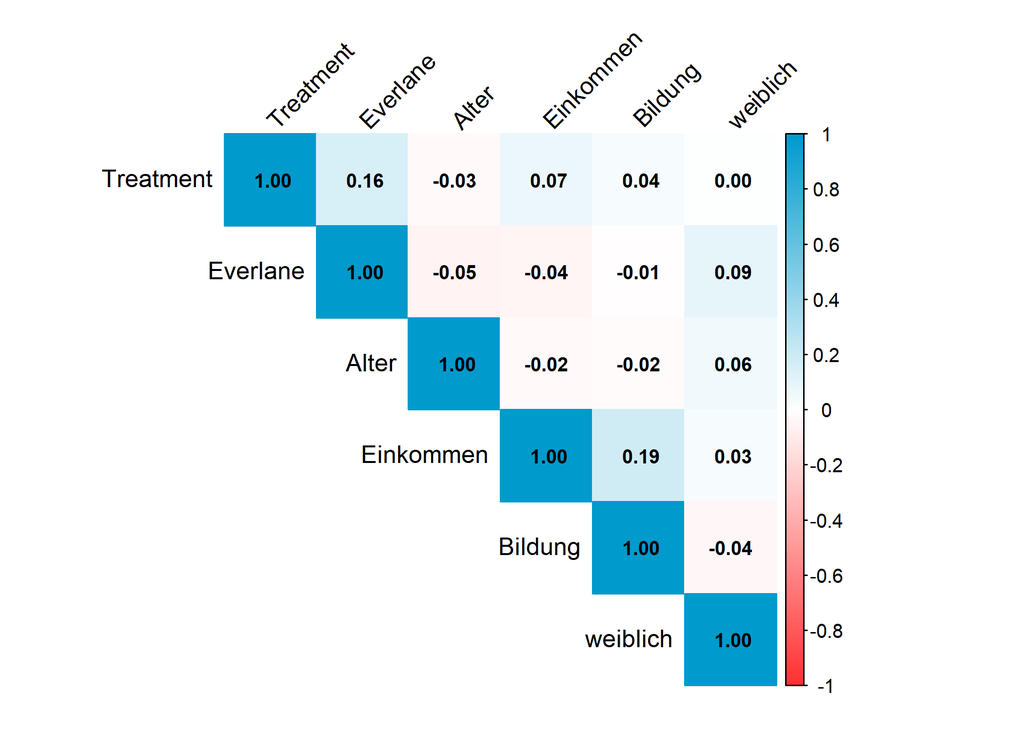

Die berechnete Korrelationsmatrix zeigt, wie verschiedene Variablen im Datensatz miteinander zusammenhängen. Eine stark positive Korrelation wird in der Tabelle blau eingefärbt, während stark negative Zusammenhänge rot eingefärbt werden. Die Variablen, die dabei untersucht werden, sind: Treatment, Everlane, Alter, Einkommen, Bildung und das Geschlecht. Besonders relevant für die Fragestellung sind die Zusammenhänge zwischen der Treatmentzugehörigkeit (ob eine Person die Kostentransparenz gesehen hat oder nicht) und der Auswahl der Everlane-Gutscheinkarte sowie den Variablen Bildung und Einkommen. Zwischen Treatment und Everlane ergibt sich eine Korrelation von 0,16. Das deutet darauf hin, dass es einen schwach positiven Zusammenhang gibt: Wer der Treatmentgruppe angehört, entscheidet sich tendenziell etwas häufiger für Everlane. Im Kontext der Hypothese, dass Kostentransparenz die Wahl zugunsten von Everlane beeinflusst, ist dies ein erster, explorativer Hinweis für einen möglichen Effekt.

Der Zusammenhang zwischen Treatment und Bildungsniveau (0,04) sowie zwischen Treatment und Einkommen (0,07) ist hingegen nahezu vernachlässigbar. Das bestätigt, dass die Randomisierung bei diesen Merkmalen offenbar erfolgreich war: Die Gruppen unterscheiden sich nicht systematisch hinsichtlich Bildung oder Einkommen.

Deutlich ausgeprägter ist mit 0,19 der positive Zusammenhang zwischen Bildung und Einkommen: Personen mit höherer Bildung haben im Mittel ein höheres Einkommen.

Trotzdem gilt: Eine Korrelation allein reicht nicht aus, um kausale Schlüsse zu ziehen – selbst bei randomisierten Experimenten. Die Korrelationsanalyse belegt nur, dass zwei Variablen gemeinsam variieren, sagt aber nichts über Ursache und Wirkung. Besonders bei sozialen Daten können Wechselwirkungen mit anderen Merkmalen oder Zufall eine Rolle spielen. Daher bilden solche Analysen einen wichtigen ersten Schritt, sollten aber immer durch weitere, gezielte Methoden ergänzt werden.

Insgesamt bietet die Korrelationsmatrix einen schnellen, umfassenden Überblick über die Struktur und mögliche Zusammenhänge im Datensatz. Sie ermöglicht es, Auffälligkeiten, zufällige oder auch unerwünschte Beziehungen frühzeitig zu erkennen, geht aber über reine Mittelwertvergleiche hinaus, da sie auch Wechselwirkungen zwischen anderen Merkmalen sichtbar macht. Solche Übersichten sind vor allem zur Überprüfung der Randomisierung und zur Vorbereitung weiterer Analysen in experimentellen Designs sehr wertvoll.

7. In Aufgabe 1 und 2 haben Sie gelesen, dass den Teilnehmern ein Angebot gemacht wurde, eine Everlane-Gutscheinkarte anzunehmen. Erzeugen Sie eine geeignete Grafik, die den durchschnittlichen Anteil der angenommenen Angebote (d.h. den Anteil, in dem die Everlane-Karte gewählt wurde) getrennt für die Treatment- und die Kontrollgruppe darstellt. Fügen Sie in der Grafik zusätzlich den Standardfehler der Mittelwerte ein. Führen Sie einen T-Test durch, um zu prüfen, ob der Unterschied im Mittelwert zwischen der Treatment- und Kontrollgruppe statistisch signifikant ist, und geben Sie das Testergebnis (den p-Wert) deutlich sichtbar in der Grafik an. Achten Sie dabei auf eine verständliche Beschriftung Ihrer Grafik sowie auf einen aussagekräftigen Titel.

Beschreiben und interpretieren Sie ihre Grafik. Gehen Sie insbesondere auf folgende Fragen ein:

- Welche Aussage lässt sich auf Basis des durchgeführten T-Tests treffen?
- Welche der in den vorherigen Aufgaben (vgl. Aufgabe 4 und 5) analysierten Faktoren könnten dazu beigetragen haben, dass ein signifikanter Unterschied im Anteil angenommener Everlane-Angebote zwischen Treatment- und Kontrollgruppe beobachtet wird?

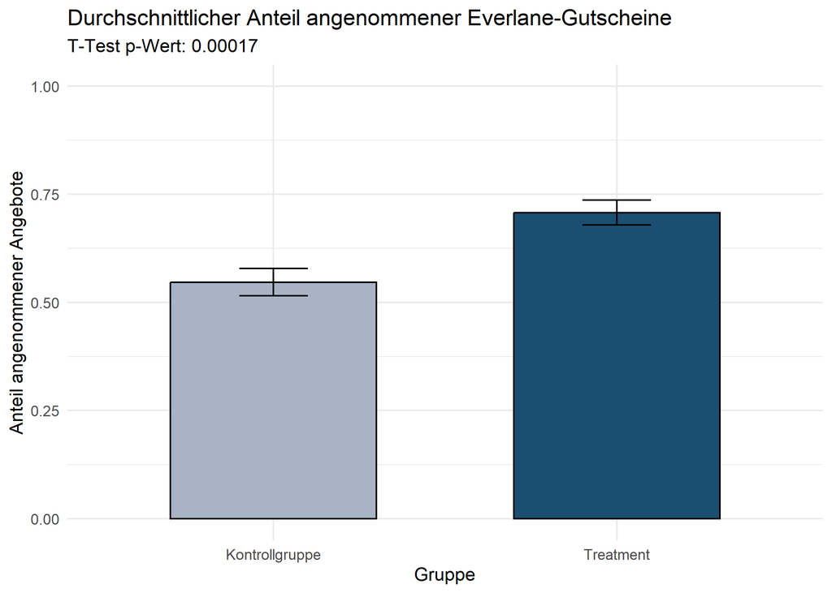

Der T-Test zeigt, dass der Unterschied im Anteil angenommener Everlane-Gutscheinkarten zwischen der Treatment- und der Kontrollgruppe statistisch signifikant ist (p-Wert < 0.05). Genauer gesagt ist der p-Wert hochsignifikant, da p < 0,01 ist. Es ist daher sehr wahrscheinlich, dass der beobachtete Effekt nicht durch Zufall, sondern durch die experimentelle Bedingung zustande kam. Daraus lässt sich schließen, dass das Treatment – also die experimentelle Manipulation – einen messbaren Einfluss auf das Verhalten der Teilnehmenden hatte, nämlich auf die Wahrscheinlichkeit, das Angebot anzunehmen.

In Aufgabe 5 haben wir festgestellt, dass keine statistisch signifikanten Unterschiede zwischen Kontroll- und Treatmentgruppe in Bezug auf Alter, Geschlecht und Bildungsniveau bestehen. Obwohl die Balancing-Tabelle zeigt, dass sich die Treatment- und Kontrollgruppe hinsichtlich zentraler Merkmale wie Alter, Geschlecht, Bildung und Einkommen nicht signifikant unterscheiden, könnten diese Variablen dennoch beeinflussen, wie stark Personen auf die Intervention reagieren. So ist es denkbar, dass etwa besser gebildete oder einkommensstärkere Personen eher auf die Kostentransparenz ansprechen, da sie stärker auf ethischen Konsum achten oder über mehr finanzielle Spielräume verfügen. Auch Alter und Geschlecht könnten eine Rolle spielen, wenn bestimmte Gruppen besonders empfänglich für transparente Unternehmenspraktiken sind. Die beobachteten Merkmale erklären zwar nicht den Unterschied in der Annahme der Everlane-Angebote, sie könnten jedoch den Effekt der Maßnahme moderieren.

In den vorherigen Aufgaben des Projekts haben Sie sich bereits intensiv mit dem Experiment 1 auseinandergesetzt, in dem untersucht wurde, ob und wie die Offenlegung von Produktionskosten - also Kostentransparenz - das Konsumverhalten beeinflusst. Es wurde gezeigt: Wenn Konsument:innen transparent mitgeteilt wird, wie sich die Kosten eines Produkts zusammensetzen, steigt ihre Bereitschaft, bei dem entsprechend transparenten Unternehmen einzukaufen.

Diese Ergebnisse legen nahe, dass die Offenlegung sensibler Unternehmensinformationen (wie Produktionskosten) das Vertrauen der Konsument:innen in das Unternehmen stärkt und sie somit eher zu einem Kauf motiviert.

Doch was genau ist der psychologische Mechanismus hinter dieser Wirkung? Ist es tatsächlich das Vertrauen in das Unternehmen, das durch die Offenlegung sensibler Informationen gestärkt wird - und in der Folge die Kaufbereitschaft erhöht?

Um genau diese Frage zu beantworten, führen die Autoren ein weiteres Experiment durch, das den vermuteten psychologischen Vermittlungsmechanismus des Vertrauens genauer untersucht. Dabei wurde geprüft, ob Vertrauen tatsächlich als Mediator zwischen Kostentransparenz und Kaufinteresse wirkt. Hierzu wurde ein kontrolliertes Online-Experiment mit über 600 Teilnehmer:innen durchgeführt. Die Teilnehmenden wurden zufällig einer von zwei Bedingungen zugewiesen:

- In der **Kostentransparenz-Gruppe** (Treatment) wurde zusätzlich eine detaillierte Aufschlüsselung der Produktionskosten angegeben. Diese beinhaltete die einzelnen Kostenkomponenten (z.B. Kakaobutter, Verpackung, Arbeitskosten) sowie die Gesamtkosten der Schokoladentafel (vgl. Abbildung 2 im Anhang).
- In der **Kontrollgruppe** sahen die Teilnehmer die Verpackung einer fiktiven Schokoladenmarke namens „Cocoa Passion“. Diese enthielt nur die üblichen Informationen wie Zutaten, Nährwerte und eine Produktbeschreibung.

Ziel war es, zu untersuchen, ob die Offenlegung dieser sensiblen Informationen das Vertrauen der Konsument:innen in die Marke stärkt - und ob dieses Vertrauen wiederum die Kaufbereitschaft beeinflusst. In den nächsten Aufgaben werden Sie diese Studie genauer beleuchten, analysieren und evaluieren, ob sich die Hypothese empirisch bestätigen lässt.

8. Lesen Sie die Daten des zweiten Experiments (`Experiment2.csv`) in R ein. Nennen Sie den Datensatz `daten_exp2`. Benennen Sie die Variable `cost` in `treatment` um.

Untersuchen Sie, ob sich die Teilnehmer, die die Verpackung mit transparenter Kosteninformation gesehen haben, systematisch von jenen unterscheiden, die nur die Kontrollversion gesehen haben.

Erstellen Sie hierfür eine Balancing-Tabelle, in der Sie die Mittelwerte von Alter (age), Geschlecht (female), Einkommensstufe (income), Bildungsniveau (educ), Vertrauen (trust) und Kaufbereitschaft (wtb) zwischen den beiden Gruppen vergleichen, die Differenzen berechnen und mithilfe von T-Tests prüfen, ob diese Unterschiede statistisch signifikant sind. Nehmen Sie weiterhin die Anzahl an Beobachtungen in der Treatment- und in der Kontrollgruppe in ihre Tabelle mit auf.

Beschreiben und interpretieren Sie ihre Tabelle. Gehen Sie dabei insbesondere auf folgende Fragen ein:

- Was versteht man unter der Variable `wtb`?
- Was lässt sich aus der Größen der Stichprobe ableiten?
- Wo könnte es bei einer Regression (oder einem sonstigen Vergleich der Gruppen) zu Problemen kommen und was wären mögliche Auswirkungen?

*Hinweis:* Für die Beschreibung der `wtb` können Sie das bereitgestellte Readme nutzen.

Balancing-Tabelle: Vergleich von Kontroll- und Treatmentgruppe

| Variable | Kontrollgruppe | Treatmentgruppe | Differenz | p-Wert |
| --- | --- | --- | --- | --- |
| Alter | 36.27 | 34.06 | -2.21 | 0.016 |
| Geschlecht | 0.42 | 0.48 | 0.05 | 0.207 |
| Einkommensstufe | 6.96 | 6.79 | -0.17 | 0.372 |
| Bildungsniveau | 3.51 | 3.57 | 0.05 | 0.443 |
| Vertrauen | 4.82 | 5.27 | 0.45 | 0 |
| Kaufbereitschaft | 3.74 | 4.27 | 0.53 | 0.001 |
| Anzahl Beobachtungen | 308 | 306 |  |  |

Zur Überprüfung der Ausgangsähnlichkeit der Experimentalgruppen wurde eine Balancing-Tabelle erstellt, in der zentrale demografische und psychologische Merkmale zwischen der Kontrollgruppe und der Treatmentgruppe verglichen wurden. Die Treatmentgruppe erhielt im Experiment zusätzliche Informationen über die Produktionskosten des Produkts, während die Kontrollgruppe lediglich die reguläre Produktverpackung sah.

Die Stichprobenverteilung ist nahezu gleichmäßig: 308 Personen in der Kontrollgruppe und 306 in der Treatmentgruppe. Diese annähernd identische Gruppengröße ist ein Indiz für eine erfolgreiche Randomisierung und sorgt für statistische Vergleichbarkeit. Im Hinblick auf die demografischen Variablen zeigen sich keine systematischen Unterschiede zwischen den Gruppen. Die Mittelwerte für Geschlecht, Einkommensstufe und Bildungsniveau unterscheiden sich statistisch nicht signifikant. Lediglich beim Alter ergibt sich ein signifikanter Unterschied: Die Teilnehmer:innen in der Treatmentgruppe sind im Durchschnitt rund zwei Jahre jünger als jene in der Kontrollgruppe (p = 0,016).

Besonders relevant für die Hypothese der Studie sind die Variablen Vertrauen (trust) und Kaufbereitschaft (wtb). Hier zeigen sich deutliche und statistisch signifikante Unterschiede: Teilnehmer:innen, die die transparente Kostenaufstellung gesehen haben, geben sowohl ein höheres Vertrauen in das Unternehmen (Mittelwert = 5,27 vs. 4,82; p-Wert < 0,001) als auch eine höhere Kaufbereitschaft an (Mittelwert = 4,27 vs. 3,74; p-Wert = 0,001).

Die Variable wtb misst die Kaufbereitschaft der Befragten mit folgender Frage: „Wenn Sie die Möglichkeit hätten, wie wahrscheinlich ist es, dass Sie dieses Produkt kaufen würden?“ Die Antwort erfolgte auf einer 7-Punkte-Skala (1 = „überhaupt nicht wahrscheinlich“ bis 7 = „sehr wahrscheinlich“). Eine höhere Ausprägung steht somit für eine stärkere Absicht, das Produkt tatsächlich zu erwerben.

Aus der hohen und übermäßig gleichmäßig verteilten Stichprobengröße lässt sich schließen, dass die statistische Aussagekraft der Ergebnisse solide ist. Dennoch ist zu beachten, dass der signifikante Altersunterschied zwischen den Gruppen ein potenzieller Störfaktor sein kann, wenn dieser Einfluss auf Vertrauen oder Kaufverhalten ausübt. In weiteren Regressionsanalysen sollte das Alter daher als Kontrollvariable berücksichtigt werden, um Verzerrungen durch Confounder zu vermeiden.

Ebenso zeigt sich bereits, dass Vertrauen durch die Treatmentbedingung beeinflusst wird – ein wichtiger Hinweis für die geplante Mediationsanalyse. Insgesamt legen die Ergebnisse nahe, dass Vertrauen eine zentrale Rolle im Wirkmechanismus zwischen Kostentransparenz und Konsumverhalten spielt.

9. In ihrem Datensatz gibt es einige Beobachtungen ohne vorhandene Werte. Behalten Sie nur die Beobachtungen bei denen vollständige Werte vorliegen. Erzeugen Sie eine geeignete Grafik, welche den durchschnittlichen Anteil der ‘Kaufbereitschaft’ im zweiten Experiment für die Treatment- und Kontrollgruppe darstellt.

Die Grafik soll:

- die Mittelwerte der Kaufbereitschaft für beide Gruppen zeigen,
- die zugehörigen Standardfehler als Fehlerbalken visualisieren und
- das Ergebnis des T-Tests, der die Mittelwertdifferenz prüft, direkt in die Grafik integrieren.

Beschreiben und interpretieren Sie ihre Grafik.

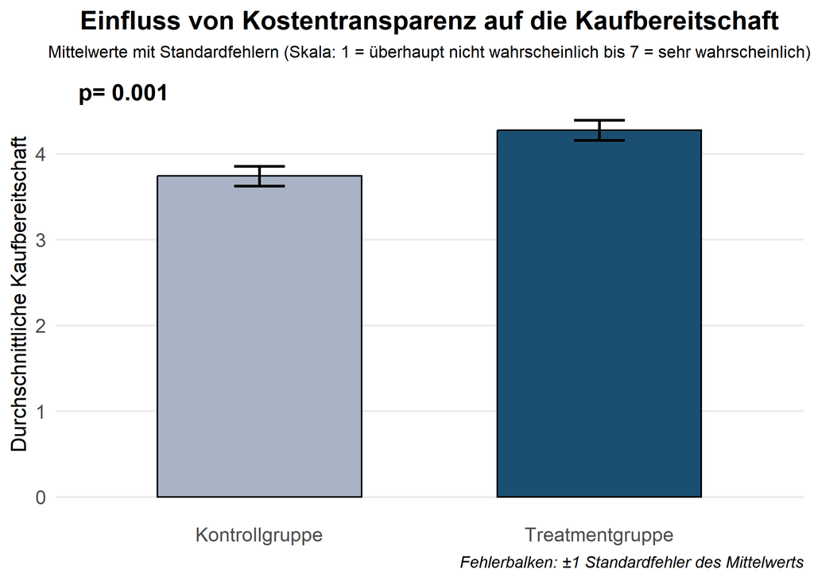

Die Grafik zeigt die durchschnittliche Kaufbereitschaft (wtb) getrennt nach Kontroll- und Treatmentgruppe, basierend auf den vollständig ausgefüllten Fragebögen des zweiten Experiments. Die Balken repräsentieren die jeweiligen Mittelwerte, die Fehlerbalken visualisieren die Standardfehler des Mittelwerts.

Die Treatmentgruppe – also jene Teilnehmer:innen, die eine Verpackung mit Kostentransparenz sahen – weist eine deutlich höhere durchschnittliche Kaufbereitschaft auf als die Kontrollgruppe. Der visuelle Eindruck wird durch den angezeigten p-Wert (z.B. p = 0.001) untermauert, der aus einem T-Test resultiert und auf eine statistisch signifikante Mittelwertdifferenz hinweist.

Diese Ergebnisse stützen die zentrale Hypothese der Studie: Transparente Kommunikation der Produktionskosten erhöht nicht nur das Vertrauen in die Marke, sondern führt auch zu einer signifikant höheren Kaufbereitschaft bei Konsument:innen.

Nachdem Sie nun die Differenzen in der Kaufabsicht zwischen der Treatment- und der Kontrollgruppe im zweiten Experiment überprüft und getestet haben, geht es im nächsten Schritt darum, den möglichen Mediator Vertrauen genauer zu untersuchen. Hierfür sollen Sie sich in einem ersten Schritt das Vertrauen der Personen allgemein anschauen, um einen Eindruck zu dieser wichtigen Variable zu bekommen. Dafür werden Personen anhand **hohem und niedrigem** Vertrauen und deren Kaufbereitschaft für das Produkt unterteilt.

10. Erstellen Sie eine oder mehrere geeignete Grafik(en), die den Zusammenhang zwischen Vertrauen (Trust) und der Kaufabsicht (WTB) **unabhängig** der beiden Treatment- und Kontrollgruppen darstellen. Achten Sie auf eine passende Darstellung der Informationen.

Die Grafik(en) sollen folgende Informationen enthalten:

- Unterteilen Sie ihre Daten in Personen mit `hohem` und `niedrigem` Vertrauen. Nutzen Sie für die Unterteilung den Median des Vertrauens in ihren Daten als Schwellenwert.
- Abhängig der Einstufungen in `hohes` und `niedriges` Vertrauen soll nun die durchschnittliche Kaufbereitschaft dargestellt werden. Hier soll die Grafik so dargestellt werden, dass auf der x-Achse das Vertrauensniveau (“hoch” und “niedrig”) und auf der y-Achse die entsprechende Kaufbereitschaft abgebildet wird.
- Berechnen Sie weiterhin die Mittelwerte der beiden Vertrauensgruppen und visualisieren diese in geeigneter Art und Weise in ihren Grafik(en).
- Führen Sie einen t-Test durch, um zu prüfen, ob die Mittelwertsunterschiede zwischen den beiden Vertrauensgruppen statistisch signifikant sind. Geben Sie den p-Wert in der Grafik an.

Beschreiben und interpretieren Sie ihre Grafik(en). Beantworten Sie insbesondere folgende Fragen:

- Welche Implikationen hat ein signifikanter Unterschied für die Rolle von Vertrauen auf Kaufentscheidungen?
- Wie stark unterscheidet sich die Kaufbereitschaft zwischen Personen mit hohem und niedrigem Vertrauen?
- Könnte auf Basis ihrer Darstellung Vertrauen als Mediator zwischen dem Treatment und der Kaufbereitschaft fungieren?

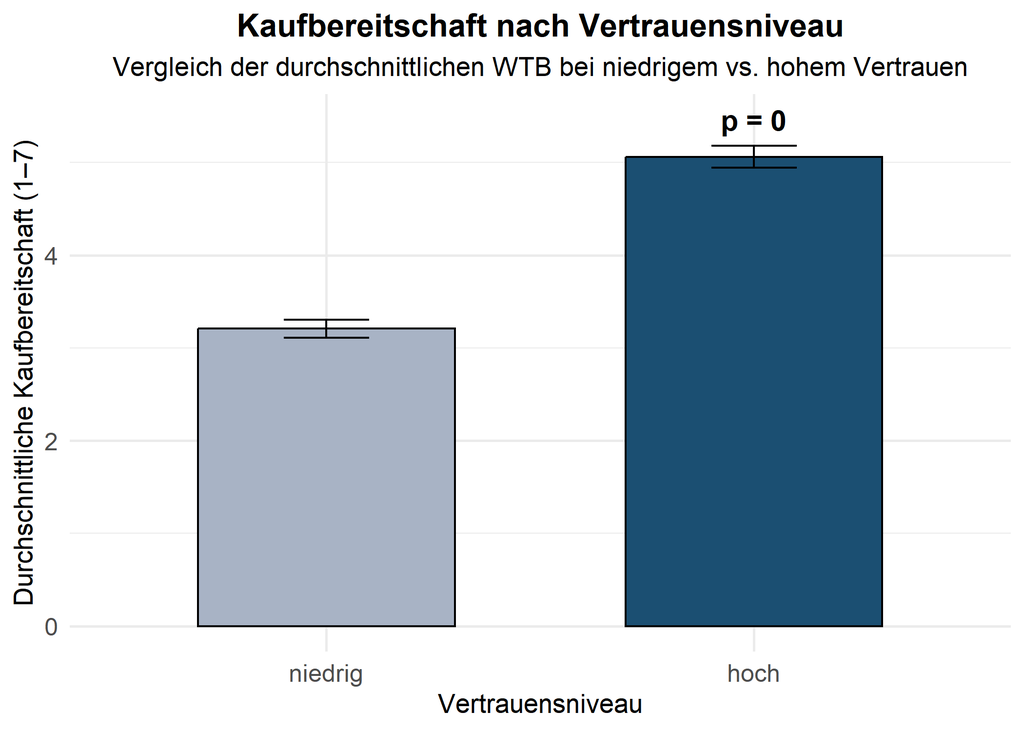

Die Grafik zeigt den Zusammenhang zwischen dem Vertrauensniveau der Personen („hoch“ vs. „niedrig“; Einteilung anhand des Medians) und ihrer durchschnittlichen Kaufbereitschaft (wtb). Jeder Balken stellt den Mittelwert der Kaufbereitschaft für Personen mit niedrigem oder hohem Vertrauen dar. Die Fehlerbalken visualisieren jeweils den Standardfehler des Mittelwerts. Der p-Wert aus einem t-Test zum Vergleich der Mittelwerte ist direkt in der Grafik angegeben.

Die Ergebnisse machen deutlich: Personen mit hohem Vertrauen in die Marke oder das Produkt haben eine durchschnittliche Kaufbereitschaft von etwas mehr als 5 auf der 7-stufigen Skala. Bei Personen mit niedrigem Vertrauen liegt die durchschnittliche Kaufbereitschaft bei etwas über 3 und damit deutlich (ca. 2 Punkte auf der Skala) niedriger. Der Unterschied zwischen den beiden Gruppen ist sehr groß und statistisch hoch signifikant (p = 0).

Diese Ergebnisse verdeutlichen, dass Vertrauen ein zentraler Einflussfaktor auf die Kaufentscheidung ist: Je größer das Vertrauen einer Person, desto eher zeigt sie die Bereitschaft, ein Produkt zu erwerben. Ein signifikanter Unterschied dieser Größenordnung impliziert, dass Maßnahmen, die Vertrauen aufbauen, große Wirkung auf die Kaufbereitschaft haben können.

Darüber hinaus legt der starke Zusammenhang zwischen Vertrauen und Kaufbereitschaft nahe, dass Vertrauen eine vermittelnde Rolle einnehmen könnte („Mediator“) – insbesondere im Kontext von Experimenten zur Kostentransparenz. Es erscheint plausibel, dass das Treatment (zum Beispiel transparente Information über Herstellungskosten) zunächst das Vertrauen der Kunden stärkt und damit indirekt die Kaufbereitschaft erhöht.

# Regressionsanalyse

Sie haben nun ihren Datensatz kennengelernt und es scheint so, als ob insbesondere Personen, welche transparente Kosten sehen, dazu neigen, das Produkt zu kaufen. Doch um ihre deskriptiven Analysen zu erhärten, wollen Sie im folgenden eine Analyse mittels Regressionen durchführen.

11. Betrachten Sie hier noch einmal das erste Experiment (`daten_exp1`). Führen Sie eine Regression durch, bei der Ihnen `everlane` als abhängige Variable dient. Als erklärende Variable nutzen Sie das `treatment`. Erstellen sie eine weitere Regression, die zusätzlich noch für die folgenden Variablen kontrolliert:
- Alter
- Bildungsstufe
- Einkommen
- Geschlecht

Stellen Sie die Regressionsergebnisse in einer Tabelle mit stargazer oder modelsummary dar!

Beschreiben und interpretieren Sie ihre Ergebnisse. Gehen Sie insbesondere auf folgende Fragen ein:

- Lässt sich der Effekt des Treatments auf die Entscheidung der Kunden kausal interpretieren?
- Ist es wichtig auf weitere Faktoren zu kontrollieren?
- Beziehen Sie sich hier auch auf die Ergebnisse aus Aufgabe 5.

Regressionsergebnisse

|  | Ohne Kontrolle | Mit Kontrolle |
| --- | --- | --- |
| Konstante | 0.547*** | 0.686*** |
|  | (0.030) | (0.132) |
| Treatment | 0.161*** | 0.155*** |
|  | (0.042) | (0.042) |
| Alter |  | -0.002 |
|  |  | (0.002) |
| Bildungsstufe |  | -0.001 |
|  |  | (0.026) |
| Einkommen |  | -0.012 |
|  |  | (0.009) |
| Weiblich |  | 0.091* |
|  |  | (0.042) |
| Num.Obs. | 509 | 505 |
| R2 | 0.028 | 0.039 |
| R2 Adj. | 0.026 | 0.030 |
| AIC | 696.8 | 690.6 |
| BIC | 709.5 | 720.1 |
| Log.Lik. | -345.416 | -338.276 |
| F | 14.376 | 4.072 |
| RMSE | 0.48 | 0.47 |

+ p < 0.1, * p < 0.05, ** p < 0.01, *** p < 0.001

Es wurden zwei Regressionen durchgeführt, um den Effekt des Treatments auf die Entscheidung der Kunden zu untersuchen. Die erste Regression beinhaltet nur als erklärende Variable `treatment`. Bei der zweiten Regression werden zusätzlich Alter, Bildungsstufe, Einkommen und Geschlecht als Kovariaten einbezogen.

In beiden Modellen ist der Effekt des Treatments positiv, signifikant und nahezu identisch (0.161*** ohne Kontrolle, 0.155*** mit Kontrolle). Das bedeutet: Das Treatment erhöht die Wahrscheinlichkeit der gewünschten Kundenentscheidung signifikant. Von den Kontrollvariablen ist nur das Geschlecht (weiblich) signifikant (0.091*, p < 0.05). Alter, Bildungsstufe und Einkommen zeigen keine signifikanten Effekte. Durch das Hinzufügen der Kontrollvariablen erhöht sich R² von 0.028 auf 0.039, was hier geringfügig ist.

Der Effekt des Treatments lässt sich kausal interpretieren. Die Randomisierung des Treatments (wie in Aufgabe 5 beschrieben) stellt sicher, dass die Zuordnung zur Treatment- und Kontrollgruppe unabhängig von beobachteten und – im Idealfall – auch unbeobachteten Merkmalen erfolgt ist. Die Balancing-Tabelle bestätigt, dass die Gruppen hinsichtlich Alter, Geschlecht, Einkommen und Bildungsniveau vergleichbar sind (keine signifikanten Unterschiede). Dadurch ist der Unterschied im Outcome zwischen den Gruppen auf das Treatment zurückzuführen und nicht auf systematische Ausgangsunterschiede. Die signifikanten Treatment-Koeffizienten in beiden Modellen spiegeln also einen kausalen Effekt wider.

Es ist sinnvoll, weitere Faktoren zu kontrollieren, auch wenn es nicht zwingend notwendig für die Kausalität ist. Da die Gruppen im Rahmen der Randomisierung im Mittel vergleichbar sind (wie die Balancing-Tabelle aus Aufgabe 5 zeigt) ist die interne Validität der kausalen Aussage grundsätzlich gewährleistet.

In unserem Ergebnis zeigt sich, dass sich der Treatment-Effekt durch die Hinzunahme der Kontrollvariablen kaum verändert (von 0.161 auf 0.155, beide p < 0.001). Dies unterstreicht die Robustheit der Schätzung und legt nahe, dass die Kausalaussage nicht von Störfaktoren verzerrt wird.

Während die bisherigen Analysen zeigen, dass das Treatment einen Effekt hat, stellt sich nun die Frage, warum das so ist. Nun sollten Sie im weiteren Verlauf durch vertiefende Regressionsanalysen prüfen, ob dies auf das Vertrauen der Kunden zurückzuführen ist. Dazu betrachten Sie noch einmal den Datensatz zu Experiment 2 (`daten_exp2`) und untersuchen, ob das Treatment (Kunden sehen transparente Kostenstruktur) zu einer höheren Kaufabsicht führt, weil sie das Vertrauen der Konsumenten in das Unternehmen stärkt.

12. Schauen Sie sich den Einfluss der Kostentransparenz auf die Kaufabsicht in den folgenden zwei Regressionen genauer an und zeigen Sie ihre Ergebnisse nebeneinander:

**1. Regression:** Abhängige Variable ist die Kaufabsicht; die erklärende Variable ist das Treatment.

**2. Regression:** Wie in der 1. Regression, doch kontrollieren Sie hier zusätzlich auf die Variablen Alter, Einkommensniveau, Bildungsstufe und Geschlecht.

Stellen Sie die Regressionsergebnisse in einer Tabelle mit stargazer oder modelsummary dar!

Beschreiben und interpretieren Sie ihre Ergebnisse allgemein. Gehen Sie weiterhin auch speziell auf folgende Fragen ein:

- Sollten die Kontrollvariablen in ihrer zweiten Regression den Koeffizienten des Treatments ändern? Was würden Sie erwarten und warum? Nutzen Sie hierzu die Ergebnisse aus Aufgabe 8.
  - Vergleichen Sie die Regressionskoeffizienten der Treatment-Variable in der ersten und zweiten Regression. Gibt es hier einen signifikanten Unterschied in der Größe des Effekts?
- Bringt ihnen die Regression Vorteile gegenüber einer reinen Darstellung der Mittelwerte wie in Aufgabe 9?
- Ist der Effekt des Treatments auf die Kaufabsicht ihrer Ansicht nach kausal interpretierbar?
  - Welche Voraussetzungen müssen erfüllt sein, damit man diesen Regressionskoeffizienten als kausalen Effekt interpretieren kann?
  - Überlegen Sie sich, wie sich das Ergebnis verändern würde, wenn zusätzlich Vertrauen (trust) in das Modell aufgenommen wird. Würde sich der Effekt von `treatment` verändern? Warum oder warum nicht?

Ergebnisse des Einflusses der Kostentransparenz auf die Kaufabsicht

|  | Ohne Kontrolle | Mit Kontrolle |
| --- | --- | --- |
| Konstante | 3.740*** | 3.702*** |
|  | (0.115) | (0.470) |
| Kostentransparenz (Treatment) | 0.533** | 0.501** |
|  | (0.163) | (0.166) |
| Alter |  | -0.013+ |
|  |  | (0.007) |
| Einkommensniveau |  | 0.023 |
|  |  | (0.036) |
| Bildungsstufe |  | 0.102 |
|  |  | (0.099) |
| Geschlecht |  | -0.001 |
|  |  | (0.168) |
| Num.Obs. | 612 | 601 |
| R2 | 0.017 | 0.025 |
| RMSE | 2.02 | 2.01 |

+ p < 0.1, * p < 0.05, ** p < 0.01, *** p < 0.001

Es wurde zunächst ein einfaches Regressionsmodell geschätzt, das die Kaufbereitschaft („wtb“) allein auf die Treatmentzugehörigkeit zurückführt. In einem zweiten Modell wurden zusätzlich Alter, Einkommensniveau, Bildungsstufe und Geschlecht als Kontrollvariablen aufgenommen, um eventuelle Unterschiede in diesen Merkmalen zwischen den Gruppen zu berücksichtigen.

Die Kontrollvariablen zeigen erwartungsgemäß kleinere oder nicht signifikante Effekte. Alter, Geschlecht und Einkommen haben keinen signifikanten Einfluss auf die Kaufbereitschaft. Dabei weist insbesondere der Koeffizient für die Bildungsstufe mit 0,102 zwar den höchsten Wert unter den Kontrollvariablen auf, ist jedoch auf keinem statistischen Signifikanzniveau bedeutsam. Das bedeutet, auch wenn der geschätzte Zusammenhang zwischen Bildung und Kaufbereitschaft relativ groß erscheint, gibt es keinen belastbaren Hinweis auf einen tatsächlichen Effekt in der Grundgesamtheit.

Wie erwartet, ändert sich der Treatment-Effekt mit Kontrolle zusätzlicher Merkmale kaum – dies bestätigt die Ergebnisse der Balancing-Tabelle aus Aufgabe 8 und spricht für eine erfolgreiche Randomisierung: Die Teilnehmenden wurden weitestgehend gleichmäßig auf die Gruppen verteilt, sodass keine Verzerrungen durch Störvariablen auftreten. Dennoch ist es methodisch sinnvoll, Kontrollvariablen in die Analyse einzubeziehen, besonders wenn es wie beim Alter kleinere Unterschiede zwischen den Gruppen gibt.

Im Vergleich zu einem reinen Mittelwertvergleich bei Aufgabe 9 bietet die Regressionsanalyse den Vorteil, dass Einflüsse durch weitere potenzielle Einflussgrößen herausgerechnet werden können. Dadurch lassen sich die Ergebnisse robuster interpretieren, auch wenn – wie hier – die Haupteffekte vergleichbar bleiben.

Da es sich um ein randomisiert-kontrolliertes Experiment handelt und die Randomisierung erfolgreich war, kann der Treatment-Koeffizient als kausaler Effekt interpretiert werden: Die erhöhte Kaufabsicht in der Treatmentgruppe ist tatsächlich auf die Kostentransparenz zurückzuführen und nicht auf Drittvariablen. Vorausgesetzt ist, dass keine systematischen Ausfälle oder andere Verzerrungen (Bsp. Attrition) im Ablauf auftreten.

Würde zusätzlich das Vertrauen (trust) als erklärende Variable in das Modell aufgenommen, wäre zu erwarten, dass sich der Treatment-Effekt abschwächt. Dies wäre der Fall, wenn ein Großteil des Effekts von Kostentransparenz auf Kaufbereitschaft über das Vertrauen vermittelt wird – man würde also einen Mediator-Effekt vermuten. In diesem Fall hätte die Treatmentzugehörigkeit einen indirekten (über Vertrauen laufenden) und einen direkten Effekt auf die Kaufabsicht.

Sie haben nun gesehen, dass es auch hier einen direkten Effekt des Treatments (transparente Kostenstrukur) auf die Kaufabsicht gibt. Doch um die dahinter liegenden Mechanismen zu verstehen, müssen Sie tiefer in psychologische Prozesse eintauchen. Experiment 2 zeigt dafür ein entsprechendes Design, um zu testen, ob Vertrauen als vermittelnder Mechanismus eine Rolle spielt. Im nächsten Schritt analysieren Sie nun selbst diese Beziehung mit theoretischen Modellen und Regressionsmethoden, um ein Gefühl dafür zu bekommen, wie sich direkte und indirekte Effekte voneinander unterscheiden.

13. Bevor Sie im nächsten Schritt ein konkretes DAG zu einem psychologischen Mediationsmechanismus erstellen, machen Sie sich zunächst mit den theoretischen Grundlagen von Directed Acyclic Graphs (DAGs) vertraut. DAGs (gerichtete azyklische Graphen) sind ein nützliches Werkzeug in der Kausalanalyse.

Beantworten Sie folgende theoretische Fragen zu DAGs:

- Wofür werden DAGs in der empirischen Forschung verwendet?
- Nennen und beschreiben Sie zwei zentrale Knotentypen in einem DAG: Confounder und Mediator.
- Worin besteht der zentrale Unterschied, ob Vertrauen als Kontrollvariable (Confounder) oder als Mediator behandelt wird - und warum ist Letzteres entscheidend für das Verständnis psychologischer Prozesse im vorliegenden Experiment?

Directed Acyclic Graphs (DAGs), zu Deutsch gerichtete azyklische Graphen, sind in der empirischen Forschung ein zentrales Werkzeug zur Darstellung und Analyse kausaler Zusammenhänge zwischen Variablen und festzustellen, welche Pfade geschlossen oder offengelassen werden müssen, um kausale Effekte korrekt zu identifizieren. Sie helfen uns dabei Kausalstrukturen transparent zu machen; Confounder (Störfaktoren), Mediatoren und Collider korrekt zu identifizieren; zu entscheiden, welche Variablen kontrolliert werden sollen, um Verzerrungen zu vermeiden; die kausale Identifizierbarkeit eines Effekts zu beurteilen.

Ein `Confounder` ist eine Variable, die sowohl das Treatment (z.B. eine Intervention) als auch das Outcome (z.B. eine Entscheidung) beeinflusst. Wird ein Confounder nicht kontrolliert, kann dies zu einer verzerrten Schätzung des kausalen Effekts führen, weil der Zusammenhang zwischen Treatment und Outcome teilweise auf den Confounder zurückzuführen ist.

Ein `Mediator` liegt auf dem kausalen Pfad zwischen Treatment und Outcome. Das Treatment beeinflusst den Mediator, und dieser wiederum das Outcome. Mediatoren erklären also, wie oder warum ein Treatment wirkt und sind zentral für das Verständnis von Wirkmechanismen.

Der zentrale Unterschied, ob Vertrauen als Confounder oder als Mediator behandelt wird, liegt darin, ob Vertrauen als gemeinsame Ursache von Treatment und Outcome betrachtet wird (Confounder) oder als vermittelnde Variable auf dem kausalen Pfad zwischen Treatment und Outcome (Mediator). Wird Vertrauen als Confounder eingestuft, geht man davon aus, dass es sowohl die Zuweisung zum Treatment als auch die Kaufabsicht beeinflusst. In diesem Fall muss Vertrauen kontrolliert werden, um einen unverzerrten Gesamteffekt des Treatments zu schätzen. Vertrauen wirkt dann störend und verfälscht die Kausalschätzung, wenn es nicht berücksichtigt wird.

Wird Vertrauen hingegen als Mediator verstanden, so nimmt man an, dass das Treatment – also die transparente Kostenstruktur – das Vertrauen der Konsument:innen kausal erhöht und dieses gestärkte Vertrauen die Kaufabsicht positiv beeinflusst. Vertrauen ist in diesem Fall ein zentraler Wirkmechanismus, durch den der Effekt des Treatments überhaupt erst zustande kommt. Deshalb wird es nicht herausgerechnet, sondern gezielt analysiert. Die Betrachtung als Mediator erlaubt es, zwischen direkten und indirekten Effekten des Treatments zu unterscheiden.

Gerade im psychologischen Kontext ist es entscheidend, Vertrauen als Mediator zu behandeln, da dies ein tieferes Verständnis darüber ermöglicht, wie und warum eine Intervention wirkt. Es reicht nicht aus zu wissen, dass ein Treatment funktioniert – entscheidend ist, durch welchen psychologischen Prozess es seine Wirkung entfaltet. Dieses Verständnis ist essenziell für die theoretische Weiterentwicklung psychologischer Modelle und die praktische Gestaltung wirksamer Interventionen.

14. Nutzen Sie nun das Directed Acyclic Graph (DAG), um die Beziehungen zwischen den Variablen Treatment (T), Vertrauen (V) und Kaufbereitschaft (K) zu analysieren und den vermuteten Mediationsmechanismus zu untersuchen.

Beschreiben und interpretieren Sie ihr DAG und die Beziehungen zwischen den Variablen. Gehen Sie insbesondere auf folgende Fragen und Aspekte ein:

- Begründen und erklären Sie die Struktur und den Aufbau ihres DAGs.
- Welche Annahmen müssen getroffen werden, damit Vertrauen tatsächlich als Mediator interpretiert werden kann?
- Welche Verzerrungen oder Störfaktoren könnten den Mediator-Effekt von Vertrauen beeinflussen? Wie könnte dies die Ergebnisse verzerren?

*Hinweis 1:* Für die Erstellung des DAGs können Sie das Paket `dagify` verwenden. Als Grundlage und Hilfsmittel können Sie die Vorlesungsfolien nutzen.

*Hinweis 2:* Eine direkte Visualisierung des DAGs in `R` ist schön, aber keine Pflicht. Sie können das DAG auch in Word/PowerPoint zeichnen und ihre Grafik mittels `include_graphics()` einfügen.

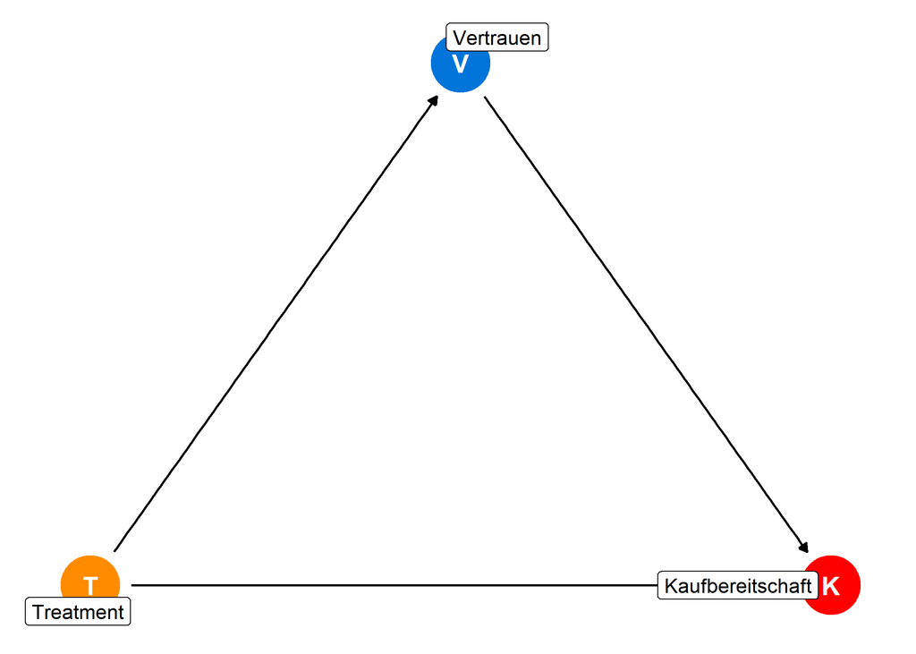

Quelle: Code und Grafik in Anlehnung an Projektkurs Simulationsstudie zur Instrumentalvariablenschätzung

Das dargestellte Directed Acyclic Graph (DAG) zeigt die vermuteten kausalen Beziehungen zwischen dem Treatment (T), Vertrauen (V) und der Kaufbereitschaft (K). Die zugrunde liegende Annahme ist, dass die transparente Kostenstruktur (T) nicht nur direkt auf die Kaufbereitschaft (K) wirkt, sondern auch indirekt über das Vertrauen der Konsument:innen vermittelt wird. Vertrauen (V) fungiert dabei als Mediator: Das Treatment soll Vertrauen stärken, und dieses gesteigerte Vertrauen soll wiederum die Kaufabsicht positiv beeinflussen. Damit besteht der Gesamtkausaleffekt des Treatments aus einem direkten Pfad (T → K) und einem indirekten Pfad (T → V → K).

Damit Vertrauen tatsächlich als Mediator interpretiert werden kann, müssen bestimmte Annahmen erfüllt sein. Zunächst muss ein kausaler Zusammenhang bestehen – sowohl vom Treatment auf Vertrauen als auch vom Vertrauen auf die Kaufbereitschaft. Darüber hinaus darf es keine unbeobachteten Drittvariablen geben, die sowohl Vertrauen als auch Kaufbereitschaft beeinflussen, da solche Confounder den vermittelten Effekt verzerren würden. Ebenso darf es keine Rückkopplung von Kaufbereitschaft auf Vertrauen geben, da das Modell gerichtete, azyklische Beziehungen voraussetzt.

Mögliche Störfaktoren, die das Ergebnis verzerren könnten, sind beispielsweise die generelle Vertrauenshaltung einer Person, frühere Erfahrungen mit dem Anbieter oder sozioökonomische Merkmale wie Einkommen und Bildung. Solche Variablen könnten sowohl Vertrauen als auch Kaufbereitschaft beeinflussen und damit zu einer Scheinkorrelation führen, wenn sie nicht kontrolliert werden. In einem erweiterten DAG müssten diese Variablen daher explizit aufgenommen oder in der empirischen Analyse berücksichtigt werden.

15. Führen Sie nun eine Regression durch, bei der Ihnen `trust` (Vertrauen) als abhängige Variable dient. Weiterhin soll ihnen `treatment` als erklärende Variable dienen. Erstellen sie eine weitere Regression, die zusätzlich noch für die folgenden Variablen kontrolliert: Alter, Einkommensniveau, Bildungsstufe und ob die Personen weiblich sind.

Stellen Sie die Regressionsergebnisse in einer Tabelle mit stargazer oder modelsummary dar!

Beschreiben und interpretieren Sie ihre Ergebnisse. Gehen Sie bei der Interpretation der Ergebnisse insbesondere auf folgende Fragen ein:

- Macht es ihrer Ansicht nach Sinn auf die zusätzlichen Variablen in Regression 2 zu kontrollieren? Worauf müssen Sie besonders achten?
- Was bedeutet ein signifikanter positiver Koeffizient für treatment in Bezug auf Vertrauen?
- Warum ist dieser Pfad (Treatment ➝ Trust) notwendig, damit eine Mediation überhaupt möglich ist?
- Überlegen Sie, ob andere Faktoren, die Sie möglicherweise nicht berücksichtigt haben, diesen Zusammenhang ebenfalls erklären könnten.

Regressionsergebnisse

|  | Ohne Kontrolle | Mit Kontrolle |
| --- | --- | --- |
| Konstante | 4.825*** | 4.716*** |
|  | (0.079) | (0.320) |
| Treatment | 0.448*** | 0.454*** |
|  | (0.111) | (0.113) |
| Alter |  | -0.001 |
|  |  | (0.005) |
| Bildungsstufe |  | 0.058 |
|  |  | (0.067) |
| Einkommen |  | -0.021 |
|  |  | (0.024) |
| Weiblich |  | 0.179 |
|  |  | (0.114) |
| Num.Obs. | 612 | 601 |
| R2 | 0.026 | 0.035 |
| R2 Adj. | 0.024 | 0.027 |
| AIC | 2133.5 | 2095.6 |
| BIC | 2146.8 | 2126.4 |
| Log.Lik. | -1063.762 | -1040.795 |
| F | 16.188 | 4.291 |
| RMSE | 1.38 | 1.37 |

+ p < 0.1, * p < 0.05, ** p < 0.01, *** p < 0.001

In der vorliegenden Analyse wurde untersucht, welchen Einfluss eine bestimmte Maßnahme (Treatment) auf das Vertrauen der Befragten hat. Dafür wurden zwei lineare Regressionsmodelle berechnet: Modell 1 enthält ausschließlich das Treatment als erklärende Variable, während Modell 2 zusätzlich soziodemografische Kontrollvariablen (Alter, Bildungsstufe, Einkommen, Geschlecht) einbezieht.

In Modell 1 zeigt sich, dass das Treatment einen positiven und hochsignifikanten Effekt auf Vertrauen hat: Der geschätzte Koeffizient beträgt 0.448 mit einem Standardfehler von 0.111, was auf ein sehr signifikantes Ergebnis (p < 0.001) hinweist. Das bedeutet: Personen in der Treatment-Gruppe berichten im Durchschnitt von einem um etwa 0.45 Punkte höheren Vertrauen als Personen in der Kontrollgruppe.

In Modell 2, in dem zusätzliche Kontrollvariablen einbezogen werden, bleibt der Effekt des Treatments mit einem Koeffizienten von 0.454 nahezu unverändert und weiterhin auf dem höchsten Signifikanzniveau (p < 0.001). Die Kontrollvariablen selbst weisen jedoch keine statistisch signifikanten Effekte auf: Alter (–0.001), Bildungsstufe (0.058), Einkommen (–0.021) und Geschlecht (0.179) haben jeweils relativ kleine, nicht signifikante Koeffizienten mit vergleichsweise hohen Standardfehlern.

Die Güte der Modelle ist insgesamt gering, was bei sozialwissenschaftlichen Fragestellungen nicht ungewöhnlich ist. Der R²-Wert steigt von 0.026 (Modell 1) auf 0.035 (Modell 2), das heißt, durch die zusätzlichen Variablen kann nur ein sehr kleiner zusätzlicher Anteil der Varianz im Vertrauen erklärt werden. Auch die Verbesserung der Modellgüte (AIC von 2133.5 auf 2095.6) ist moderat, aber messbar.

Es ist sinnvoll, auf zusätzliche Variablen zu kontrollieren (auch wenn sie im konkreten Fall keine signifikanten Effekte zeigen). Durch die Kontrolle von Alter, Bildung, Einkommen und Geschlecht kann ausgeschlossen werden, dass der beobachtete Zusammenhang zwischen Treatment und Vertrauen durch andere Faktoren verzerrt wird. In diesem Fall zeigt der nahezu identische Treatment-Koeffizient in beiden Modellen (0.448 vs. 0.454), dass der Effekt robust ist. Gleichzeitig sollte man aber darauf achten, nicht unnötig viele irrelevante Variablen in das Modell aufzunehmen, da dies die Schätzgenauigkeit verschlechtern kann.

Der signifikante positive Koeffizient für Treatment (0.448 ohne Kontrolle, 0.454 mit Kontrolle; jeweils p < 0.001) zeigt, dass die Teilnahme an der Treatment-Bedingung das Vertrauen signifikant erhöht. Das heißt: Personen im Treatment zeigen im Durchschnitt ein höheres Vertrauen als Personen in der Kontrollgruppe

Damit eine Mediation überhaupt möglich ist, muss ein signifikanter Zusammenhang zwischen Treatment und Vertrauen bestehen. Nur wenn Treatment einen Einfluss auf Vertrauen hat, kann Vertrauen als Mediator für weitere Zusammenhänge in Betracht gezogen werden. Der Pfad Treatment ➝ Trust ist somit eine notwendige Voraussetzung für die Prüfung von Mediationseffekten. Dieser Pfad ist in beiden Modellen klar gegeben (p < 0.001).

Es ist möglich, dass weitere unbeachtete Variablen (z.B. Persönlichkeit, soziale Einflüsse, frühere Erfahrungen) das Vertrauen beeinflussen. Diese könnten zu einer Verzerrung der Schätzung führen, wenn sie sowohl mit Treatment als auch mit Vertrauen zusammenhängen und nicht kontrolliert wurden. Solche unbeachteten Faktoren sollten in zukünftigen Analysen berücksichtigt werden, um den Zusammenhang noch robuster abzusichern.

16. Nachdem Sie nun den Effekt des Treatments auf das Vertrauen geschätzt und ausgewertet haben, sollen Sie nun testen, ob das Vertrauen als Mediator zwischen Treatment und Kaufabsicht wirkt.

Führen Sie eine Regression durch, bei der Ihnen die Kaufbereitschaft als abhängige Variable dient. Weiterhin sollen die erklärende Variablen nun `treatment`, sowie das Vertrauen (`trust`) umfassen. Erstellen sie eine weitere Regression, die zusätzlich noch auf Alter, Einkommensniveau, Bildungsstufe und ob die Personen weiblich sind, kontrolliert.

Stellen Sie die Regressionsergebnisse passend in einer Tabelle dar!

Beschreiben und interpretieren Sie ihre Ergebnisse. Gehen Sie bei der Interpretation der Ergebnisse insbesondere auf folgende Fragen ein:

- Was könnten Ihrer Ansicht nach Gründe sein, dass `treatment` jetzt nicht mehr signifkant ist? Woran könnt das im Detail liegen?
- Warum ist es wichtig, `trust` und `treatment` gemeinsam in einem Modell zu betrachten?
- Warum könnte `trust` eine “notwendige Bedingung” sein, damit Transparenz der Kostenstruktur zu höherer Kaufbereitschaft führt?

Regressionsergebnisse: Einfluss des Treatments und Vertrauens auf Kaufabsicht

|  | Ohne Kontrolle | Mit Kontrolle |
| --- | --- | --- |
| Konstante | -0.120 | -0.155 |
|  | (0.259) | (0.457) |
| Treatment | 0.174 | 0.129 |
|  | (0.139) | (0.140) |
| Vertrauen | 0.800*** | 0.818*** |
|  | (0.050) | (0.050) |
| Alter |  | -0.013* |
|  |  | (0.006) |
| Einkommen |  | 0.041 |
|  |  | (0.030) |
| Bildungsstufe |  | 0.055 |
|  |  | (0.082) |
| Weiblich |  | -0.148 |
|  |  | (0.140) |
| Num.Obs. | 612 | 601 |
| R2 | 0.310 | 0.327 |
| R2 Adj. | 0.308 | 0.320 |
| AIC | 2386.2 | 2337.7 |
| BIC | 2403.9 | 2372.9 |
| Log.Lik. | -1189.104 | -1160.835 |
| F | 137.018 | 48.027 |
| RMSE | 1.69 | 1.67 |

+ p < 0.1, * p < 0.05, ** p < 0.01, *** p < 0.001

Wir schätzen zwei lineare Regressionsmodelle: ein Modell mit Treatment (Konstentransparenz) und Vertrauen als erklärende Variablen (Modell 1), gefolgt von einem erweiterten Modell, das zusätzlich für demografische Kovariaten wie Alter, Einkommen, Bildungsniveau und Geschlecht kontrolliert (Modell 2). Die Ergebnisse zeigen, dass das Vertrauen in beiden Modellen einen hochsignifikanten und starken positiven Einfluss auf die Kaufabsicht hat (β ≈ 0.8, p < 0.001). Im Gegensatz dazu zeigt sich für Treatment in keinem der Modelle ein signifikanter Einfluss. Während der Effekt in Modell 1 noch positiv, aber nicht signifikant ist (β = 0.174, p > 0.1), wird er in Modell 2 sogar etwas kleiner (β = 0.129, p > 0.1). Ein möglicher Grund dafür, dass Treatment in beiden Modellen nicht signifikant ist, liegt darin, dass der Effekt des Treatments auf die Kaufabsicht vollständig oder überwiegend über das Vertrauen vermittelt wird. Das spricht für einen Mediationszusammenhang: Die Transparenzmaßnahme beeinflusst zunächst das Vertrauen der Konsumenten, welches wiederum die Kaufabsicht stärkt. Sobald trust in das Regressionsmodell aufgenommen wird, wird der direkte Effekt von treatment abgeschwächt – ein klassisches Indiz für einen vermittelnden Effekt. Darüber hinaus könnte auch eine gewisse Überschneidung in der erklärten Varianz von Treatment und Vertrauen vorliegen, was zu einer Erhöhung der Standardfehler und damit zur statistischen Unsicherheit hinsichtlich des Treatment-Effekts führen kann. Es ist daher zentral, Treatment und Vertrauen gemeinsam im Modell zu betrachten, um direkte und indirekte Effekte voneinander abgrenzen zu können. Ohne diese gemeinsame Betrachtung bliebe unklar, ob das Treatment wirklich direkt die Kaufabsicht beeinflusst oder ob sein Effekt vollständig durch eine Veränderung im Vertrauen vermittelt wird. Zudem erscheint Vertrauen als notwendige Bedingung, dass Transparenzmaßnahmen überhaupt wirken können. Transparente Informationen über eine Kostenstruktur entfalten ihre positive Wirkung auf die Kaufabsicht nur dann, wenn potentielle Kunden diesen Informationen auch Glauben schenken. Ohne ein gewisses Maß an Vertrauen könnte die Transparenzmaßnahme sogar negativ oder als manipulativ wahrgenommen werden.

In den vorangegangenen Modellen wurde untersucht, ob das Treatment (Kostentransparenz) das Vertrauen in das Unternehmen beeinflusst und ob Vertrauen wiederum mit der Kaufabsicht zusammenhängt.

17. Bewerten Sie das experimentelle Design der Studie 2. Gehen Sie dabei auch darauf ein, inwiefern Ihre Ergebnisse aus Aufgabe 13 bis 16 das theoretische Verständnis von Vertrauensbildung in der Konsumentenpsychologie bestätigt oder infrage stellt. Welche Stärken und Schwächen sehen Sie bezüglich der internen Validität und der Kausalitätsaussagen? Diskutieren Sie zudem kurz, inwiefern die Ergebnisse auf andere Bevölkerungsgruppen oder kulturelle Kontexte übertragbar sind.

*Hinweis:* Informationen zum Verständnis der Vertrauensbildung in der Konsumentenpsychologie können Sie [in dem folgenden Artikel](https://www.shs-conferences.org/articles/shsconf/pdf/2021/26/shsconf_appsconf2021_03019.pdf) auf Seite 2 bis 5 nachlesen.

Die Studie 2 untersucht den Einfluss einer transparenten Kostenstruktur auf das Vertrauen von Konsument:innen und deren Kaufabsicht. Das experimentelle Design basiert auf einer Vergleichsstruktur zwischen einer Treatment- und einer Kontrollgruppe. Ziel ist es, den vermittelnden Effekt von Vertrauen zwischen Intervention und Kaufbereitschaft empirisch zu prüfen. Dabei werden lineare Regressionsmodelle eingesetzt, wobei in einer zweiten Modellvariante zusätzlich demografische Kontrollvariablen berücksichtigt werden. Dieses Design ermöglicht grundsätzlich kausale Schlussfolgerungen, weist aber auch einige Einschränkungen auf.

Stärken des experimentellen Designs liegen in der klaren Hypothesenprüfung sowie in der theoretisch fundierten Betrachtung von Vertrauen als Mediator. Die Ergebnisse zeigen, dass das Treatment einen signifikanten und stabilen positiven Effekt auf das Vertrauen der Befragten hat – unabhängig von demografischen Kontrollvariablen. Dies bestätigt, dass Transparenzmaßnahmen das Vertrauen der Konsument:innen tatsächlich stärken können. Zudem zeigt sich, dass Vertrauen einen starken und signifikanten Einfluss auf die Kaufabsicht ausübt, während das Treatment selbst – bei gleichzeitiger Kontrolle von Vertrauen – keinen signifikanten direkten Effekt mehr auf die Kaufabsicht zeigt. Dies spricht deutlich für einen Mediationszusammenhang: Die Wirkung der Transparenzmaßnahme auf die Kaufabsicht erfolgt überwiegend oder ausschließlich über das Vertrauen.

Diese Befunde bestätigen das theoretische Verständnis von Vertrauen als zentralem Wirkmechanismus in der Konsumentenpsychologie, wie es auch im Artikel zur Vertrauensbildung erläutert wird. Vertrauen wird dabei nicht als Störfaktor (Confounder), sondern als vermittelnde Variable (Mediator) betrachtet. Damit werden psychologische Prozesse sichtbar gemacht, die erklären, warum eine Intervention wie Transparenz überhaupt wirksam ist. Die empirischen Ergebnisse aus den Aufgaben 13 bis 16 stützen diesen Ansatz ausdrücklich, indem sie sowohl den Pfad vom Treatment zum Vertrauen als auch den Pfad vom Vertrauen zur Kaufabsicht empirisch belegen. Der Verlust der Signifikanz des direkten Effekts des Treatments nach Einbezug von Vertrauen stellt somit ein klassisches Muster einer vollständigen Mediation dar.

Hinsichtlich der internen Validität zeigt sich ein gemischtes Bild. Zwar belegen die Modelle robuste Zusammenhänge, und durch die Kontrolle einiger demografischer Variablen wird versucht, mögliche Verzerrungen zu vermeiden. Allerdings bleibt unklar, ob die Zuteilung zum Treatment randomisiert erfolgte. Ohne echte Randomisierung besteht die Gefahr systematischer Unterschiede zwischen den Gruppen. Hinzu kommt, dass potenziell relevante Drittvariablen – etwa Persönlichkeitsmerkmale, frühere Erfahrungen mit ähnlichen Angeboten oder kulturell geprägte Vertrauenshaltungen – nicht berücksichtigt wurden. Diese unbeobachteten Confounder könnten die Ergebnisse verzerren und schränken die interne Validität sowie die Stärke der Kausalaussagen ein.

Auch die externe Validität der Studie ist begrenzt. Vertrauen ist eine psychologische Größe, die stark von kulturellen und sozialen Kontexten abhängt. Die Wirksamkeit transparenter Kommunikationsmaßnahmen kann in verschiedenen Kulturen unterschiedlich ausfallen, etwa in kollektivistisch geprägten Gesellschaften, in denen soziale Normen und zwischenmenschliche Beziehungen einen stärkeren Einfluss haben. Darüber hinaus liegen keine Informationen über die Zusammensetzung der Stichprobe hinsichtlich Diversität oder Repräsentativität vor. Es ist daher fraglich, inwiefern die Ergebnisse auf andere Bevölkerungsgruppen oder kulturelle Kontexte übertragbar sind.

Insgesamt lässt sich festhalten, dass das experimentelle Design der Studie gut geeignet ist, um theoretisch fundierte Hypothesen zur Vertrauensbildung zu prüfen. Die empirischen Ergebnisse unterstützen das theoretische Modell der Mediation durch Vertrauen überzeugend. Dennoch sollten künftige Studien auf eine noch stärkere Kontrolle möglicher Confounder achten und die Generalisierbarkeit der Ergebnisse systematischer untersuchen.

# Zusatzaufgabe

Zu Beginn des Projektes hatten wir erwähnt, dass die Experimente, welche im Projekt durchgeführt wurden, auf Grund eines Missgeschicks in der Online-Darstellung von unterschiedlichen Produkten zustande kam. Hier wurden von einem privat geführten Online-Händler Geldbörsen in fünf Farbvarianten angeboten, wobei beabsichtigt war, allen Farben eine einheitliche Kostentransparenz-Infografik zuzuordnen. Aufgrund eines Versehens wurde die Infografik jedoch nur bei drei Farben implementiert. Dieses zufällige Ereignis führte zu einer klaren Trennung zwischen den Produkten mit dieser und ohne diese Infografik. Das dadurch entstandene natürliche Experiment sollen Sie sich in der Zusatzaufgabe näher anschauen.

18. Lesen Sie sich den nachfolgenden Text zum Aufbau des natürlichen Experiments innerhalb dieses Papers durch und beantworten anschließend nachfolgende Fragen:

On December 2, 2013, a privately held online retailer launched a holiday gift shop with a single email to its mailing list, promoting a leather wallet offered in five colors (burgundy, black, grey, bone, and tan) and priced at $115.00. Later, at the end of January, to boost post-holiday sales, the retailer decided to add a cost transparency infographic to the online product detail pages for each of the wallet’s five color combinations. The retailer’s intention was to use the same infographic for all wallets since they differed only in color.

However, due to an inadvertent mistake, the infographic was not introduced for two of the wallet colors (bone and tan). Consequently, the cost transparency information was implemented for only three of the five wallet colors (burgundy, black, and grey) over a period of five weeks. This error created a natural experiment, enabling us to test the impact of cost transparency on wallet sales.

Therefore we have the following procedure:

- Operationalization of Cost Transparency: The infographic presented the total cost to produce the wallet, breaking it down into its specific components, namely: leather (14.68 US-Dollar), construction (38.56 US-Dollar), duties (4.26 US-Dollar), and transportation (1.00 US-Dollar). In addition, it included benchmark information indicating that the wallet had a 1.9x markup, in contrast to a 6x markup charged by a competitor. Because wallet colors serve as the basis for treatment assignment, the natural experiment compares “cost transparent” wallets (burgundy, black, and grey) to “non-transparent” wallets (bone and tan).
- Identification Strategy: We use a difference-in-differences approach to compare the daily sales between the treatment (cost transparency) and control (no cost transparency) groups before versus after the introduction of the infographic. By doing so, the design isolates the causal effect of cost transparency on the daily count of wallets sold for each color.
- Control Variables: Given that the cost transparency treatment was implemented by wallet color, and with only five available colors, it was necessary to control for potential confounders. For instance, we include a proxy for time-varying color popularity - the number of page views each wallet color received - and a proxy for time-varying inventory levels.

Beantworten Sie nun die folgenden Fragen in Bezug auf den vorherigen Text:

- Wie ist das natürliche Experiment aufgebaut, und warum wird es als solches klassifiziert?
- Welche Rolle spielt das zufällige Versäumnis, die Infografik bei zwei der fünf Farbvarianten einzuführen, in der Experimentstruktur?
- Warum ist es notwendig, Variablen wie Seitenaufrufe und Lagerbestandsproxies in die Analyse einzubeziehen?
  - Welche potenziellen Verzerrungen könnten auftreten, wenn diese Kontrollvariablen nicht berücksichtigt werden?

Das natürliche Experiment in diesem Fall entstand durch ein unbeabsichtigtes Versäumnis in der Online-Darstellung eines Produkts – konkret: eines Lederportemonnaies in fünf Farbvarianten. Ziel des Online-Händlers war es, bei allen Farbvarianten eine einheitliche Kostentransparenz-Infografik zu implementieren. Aufgrund eines Fehlers wurde diese Infografik jedoch nur bei drei der fünf Farben (burgundy, black, grey) angezeigt, während sie bei den Farben bone und tan fehlte. Da diese Zuordnung nicht absichtlich und damit unabhängig von anderen Verkaufs- oder Produkteigenschaften erfolgte, handelt es sich um ein sogenanntes natürliches Experiment. Es ist „natürlich“, weil die Einteilung in Behandlungs- (mit Infografik) und Kontrollgruppe (ohne Infografik) nicht bewusst durch die Forschenden oder den Händler vorgenommen wurde, sondern sich durch ein zufälliges Ereignis ergab. Diese Zufälligkeit ist entscheidend, da sie die Voraussetzung für eine glaubwürdige kausale Identifikation schafft, vergleichbar mit einer Randomisierung in einem kontrollierten Experiment.

Das versehentliche Auslassen der Infografik bei zwei Farbvarianten ist somit zentral für die Struktur des Experiments, da es die Vergleichsgruppen begründet. Es ermöglicht eine differenzierte Betrachtung der Verkaufszahlen zwischen den Farben mit und ohne Transparenzinformation, ohne dass diese Gruppen systematisch durch andere Merkmale (z.B. Qualität, Preis, Zielgruppe) geprägt wären. Die Farbe dient als natürliche Zuordnungsvariable, wobei nur ein Aspekt – die Transparenzinformation – systematisch variiert wurde.

Um sicherzustellen, dass Unterschiede in den Verkaufszahlen tatsächlich auf die Kostentransparenz zurückzuführen sind und nicht auf andere Faktoren, ist es notwendig, bestimmte Kontrollvariablen in die Analyse einzubeziehen. Dazu zählen beispielsweise die Anzahl der Seitenaufrufe je Farbvariante als Proxy für die jeweilige Beliebtheit oder Sichtbarkeit eines Produkts sowie Informationen über den Lagerbestand. Diese Variablen kontrollieren für Unterschiede in der Nachfrage oder Verfügbarkeit, die unabhängig von der Behandlung (also der Infografik) sein könnten.

Würde man diese Kontrollvariablen nicht berücksichtigen, könnten Verzerrungen auftreten: So könnte etwa eine Farbvariante mehr verkauft worden sein, weil sie zufällig häufiger aufgerufen wurde – nicht weil die Infografik einen Effekt hatte. Ebenso könnten Farben mit geringerem Lagerbestand seltener verkauft worden sein, was fälschlicherweise als Wirkung der fehlenden Transparenz interpretiert würde. Durch die Einbeziehung dieser Variablen wird sichergestellt, dass die beobachteten Unterschiede tatsächlich auf die eingeführte Kostentransparenz zurückzuführen sind - und nicht auf externe Störfaktoren.

19. Lesen Sie weiterhin das Kapitel [“Difference-in-Differences” in Huntington-Klein (2021)](https://theeffectbook.net/ch-DifferenceinDifference.html), speziell Kapitel 18.1 und 18.2 und beantworten Sie die folgenden Fragen dazu:

Kann eine Difference-in-Differences-Regression helfen, den kausalen Effekt der Kostentransparenz auf die Verkaufszahlen zu identifizieren?

Gehen Sie bei der Beantwortung dieser Frage insbesondere auf die nachfolgenden Punkte ein:

- Welche Art von Variation nutzt eine DiD-Regression in diesem Fall zur Identifikation des Effekts?
- Welche Voraussetzung(en) müssen erfüllt sein, damit DiD eine gültige Kausalschätzung liefert?
  - Was bedeutet die „Parallel Trends“-Annahme in diesem Kontext?
  - Warum reicht es nicht aus, nur zu vergleichen, wie sich die Verkaufszahlen nach der Einführung verändert haben?
- Basierend auf dem Kontext des Buchkapitels zu Difference-in-Differences (DiD) und den Informationen aus `Aufgabe 18`, formulieren Sie bitte die **Regressionsgleichung**, mit der der Effekt der Kostentransparenzmaßnahme mithilfe eines DiD-Ansatzes untersucht werden kann.
  - Definieren Sie dabei klar alle verwendeten Variablen.
  - Stellen Sie die Regressionsgleichung in mathematischer Form dar.
  - Beschreiben und erklären Sie das von Ihnen aufgestellte Modell.

Eine Difference-in-Differences (DiD)-Regression kann grundsätzlich helfen, den kausalen Effekt der Kostentransparenz auf die Verkaufszahlen zu identifizieren, aber unter bestimmten Voraussetzungen.

Damit DiD eine gültige Kausalschätzung liefert, müssen folgende zentrale Voraussetzungen erfüllt sein. Die wichtigste Voraussetzung ist die Parallel Trends-Annahme (Annahme paralleler Trends). Sie besagt: “Wenn die Kostentransparenzmaßnahme nicht eingeführt worden wäre, hätten sich die Verkaufszahlen in der behandelten und der Kontrollgruppe im Zeitverlauf gleich (parallel) verändert”. Das bedeutet, alle zeitlichen Effekte, die beide Gruppen betreffen (z.B. allgemeine Konjunktur, Saisonalität), werden durch die Veränderung in der Kontrollgruppe repräsentiert. Nur die zusätzliche Veränderung in der behandelten Gruppe nach Einführung der Maßnahme kann dann dem Effekt der Kostentransparenz zugeordnet werden.

Ein bloßer Vorher-Nachher-Vergleich in der behandelten Gruppe kann nicht kausal interpretiert werden, weil sich Verkaufszahlen auch aus anderen Gründen verändern können (z.B. saisonale Effekte, allgemeine Trends, externe Schocks). Erst durch den Vergleich mit einer Kontrollgruppe, die nicht behandelt wurde, kann man diese allgemeinen Effekte herausrechnen und so den kausalen Effekt isolieren.

Mathematische Form: Y<sub>it</sub> = β<sub>0</sub> + β<sub>1</sub>⋅Treated<sub>i</sub> + β<sub>2</sub>⋅Post<sub>t</sub> + β<sub>3</sub>⋅(Treated<sub>i</sub> × Post<sub>t</sub>) + ϵ<sub>it</sub>

β<sub>0</sub>: Durchschnittliche Verkaufszahlen der Kontrollgruppe vor der Maßnahme

β<sub>1</sub>: Unterschied zwischen Behandlungs- und Kontrollgruppe vor der Maßnahme

β<sub>2</sub>: Veränderung über die Zeit in der Kontrollgruppe

β<sub>3</sub>: DiD-Schätzer → Kausaler Effekt der Kostentransparenzmaßnahme auf die Verkaufszahlen (unter Parallel-Trends-Annahme)

Beschreibung der Variablen:

Post<sub>t</sub>: Dummy-Variable, 1 wenn Zeitpunkt t nach der Einführung der Maßnahme liegt, sonst 0

(Treated<sub>i</sub> × Post<sub>t</sub>): Interaktionsterm, der 1 ist, nur wenn Einheit behandelt und nach der Maßnahme beobachtet wird

ϵ<sub>it</sub>: Fehlerterm

Dieses Modell schätzt den Effekt der Kostentransparenzmaßnahme, indem es die durchschnittlichen Veränderungen in der behandelten und der unbehandelten Gruppe vor und nach der Einführung vergleicht. Der zentrale Parameter ist β<sub>3</sub>: Er gibt an, um wie viel sich die Verkaufszahlen in der behandelten Gruppe zusätzlich verändert haben, nachdem die Maßnahme eingeführt wurde, im Vergleich zur Kontrollgruppe. Nur wenn die Parallel Trends-Annahme gilt, kann β3 als kausaler Effekt interpretiert werden.

20. Zum Abschluss des Projekts sollen Sie sich das oben beschriebene natürliche Experiment genauer anschauen. Lesen Sie hierzu die Daten (`Experiment3.csv`) in R ein. Nennen Sie den Datensatz `daten_exp3`. Erstellen Sie eine Variable `log_units`, die die logarithmierte Anzahl an verkauften Einheiten darstellt.

Erstellen Sie weiterhin eine passende Grafik, die die durchschnittliche Anzahl der verkauften Produkte je Treatment pro Woche abbildet. Fügen Sie weiterhin eine vertikale Linie für den 28. Januar 2014 in ihre Grafik ein, welche die Einführung der Kostentransparenz markiert.

Beschreiben und interpretieren Sie ihre Grafik. Gehen Sie insbesondere auf die Entwicklung der durchschnittlichen Verkaufszahlen in beiden Gruppen vor und nach dem 28. Januar ein. Gibt es visuelle Hinweise auf eine Wirkung der Kostentransparenz?

- Angenommen, beide Gruppen (Treatment und Kontrolle) zeigen vor der Einführung der Kostentransparenz einen gleich starken Anstieg der durchschnittlich verkauften Einheiten. Was würde das für die Interpretation der Maßnahme im Rahmen eines Difference-in-Differences-Ansatzes bedeuten?

*Hinweis:* Für die Ableitung der Wochen aus dem Datumsformat kann die Funktion `isoweek()` aus dem Paket `lubridate` verwendet werden.

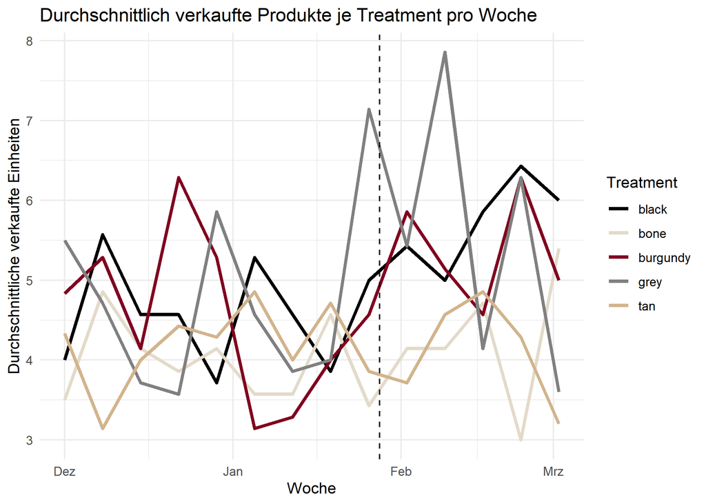

Die Grafik zeigt die durchschnittlich verkauften Einheiten pro Woche für verschiedene Gruppen, unterschieden nach der jeweiligen Farbe (beispielsweise „burgundy“, „black“, „grey“ usw.). Die vertikale Linie markiert den 28. Januar 2014 – den Zeitpunkt der Einführung der Kostentransparenz. Ziel der Darstellung ist es, zu überprüfen, ob es Hinweise auf eine Wirkung dieser Maßnahme auf das Kaufverhalten gibt.

Im Rahmen eines Difference-in-Differences (DiD)-Ansatzes ist eine zentrale Voraussetzung, dass die Gruppen vor der Maßnahme (also vor dem 28. Januar) einem parallelen Trend folgen. Das bedeutet: Beide Gruppen sollten sich in der Zeit vor der Intervention ähnlich entwickeln, sodass sich mögliche Unterschiede nach der Intervention kausal auf die Maßnahme zurückführen lassen. Wenn die Verkaufszahlen in beiden Gruppen vor dem 28. Januar tatsächlich einen gleich starken Anstieg zeigen, wäre diese Paralleltrendannahme erfüllt. In diesem Fall könnte ein nachträglicher, gruppenspezifischer Anstieg (z.B. nur in der Treatment-Gruppe) als kausale Wirkung der Kostentransparenz interpretiert werden.

Zusammenfassend lässt sich sagen, dass die Grafik visuelle Hinweise auf einen möglichen Effekt der Kostentransparenz bietet. Um jedoch belastbare Schlussfolgerungen zu ziehen, wäre eine formale Difference-in-Differences-Analyse notwendig.

21. Erstellen Sie eine (mehrere) weitere passende Grafik(en), die die durchschnittlich verkauften Einheiten pro Tag in Treatment und Kontrolle vor und nach der Einführung der Kostentransparenz abbildet. Ergänzen Sie in ihrer Grafik die jeweiligen Standardfehler als Fehlerbalken. Beschreiben und interpretieren Sie ihre Grafik. Gehen Sie insbesondere auf die Unterschiede vor und nach der Einführung der Kostentransparenz ein.
- Inwiefern lassen sich daraus erste Hinweise auf einen möglichen Effekt des natürlichen Experiments erkennen?

*Hinweis:* Für die Erstellung der Grafik können Sie sich an Aufgabe 7 und 9 orientieren.

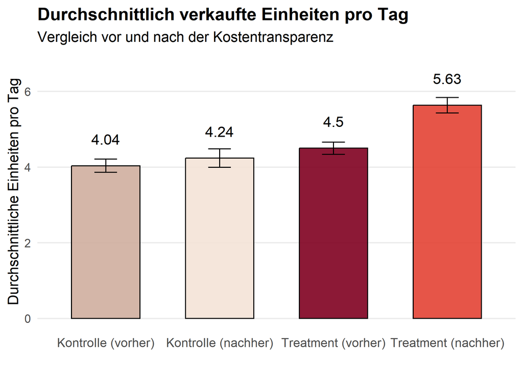

Zur Beurteilung des Effekts der Einführung von Kostentransparenz wurde eine Grafik erstellt, die die durchschnittlich verkauften Einheiten pro Tag für die Treatment- und Kontrollgruppe sowohl vor als auch nach dem Stichtag (28. Januar 2014) zeigt. Die Darstellung erfolgt mittels eines Balkendiagramms mit zusätzlichen Fehlerbalken, die die Standardfehler der jeweiligen Mittelwerte angeben und somit Rückschlüsse auf die statistische Präzision der Schätzungen ermöglichen.

Die Analyse zeigt, dass sich die Verkaufszahlen in der Kontrollgruppe über den Zeitraum hinweg kaum verändert haben. Vor der Einführung der Kostentransparenz lag der durchschnittliche Absatz pro Tag in der Kontrollgruppe bei rund 4,04 Einheiten, danach stieg dieser nur minimal auf 4,24 Einheiten an. Diese Veränderung ist gering und fällt wahrscheinlich nicht signifikant ins Gewicht.

Im Gegensatz dazu ist in der Treatmentgruppe ein deutlich stärkerer Anstieg zu beobachten. Vor der Einführung der Transparenz lag der durchschnittliche Tagesabsatz hier bei 4,5 Einheiten. Nach dem Stichtag erhöhte sich dieser auf rund 5,63 Einheiten pro Tag. Damit ist ein Anstieg von über einer Einheit pro Tag festzustellen, was auf einen substanziellen Effekt der Maßnahme hindeutet.

Insgesamt liefert die Grafik somit erste Hinweise auf einen positiven Effekt der eingeführten Kostentransparenz auf den Absatz in der Treatmentgruppe.

22. In der vorherigen Aufgabe haben Sie den Effekt von Kostentransparenz auf die Verkaufszahlen anhand eines deskriptiven Vergleichs untersucht. Dabei haben Sie die durchschnittlich täglich verkauften Einheiten je Treatment vor und nach der Einführung der Transparenzmaßnahme grafisch gegenübergestellt. In dieser Aufgabe sollen Sie diesen Effekt nun ökonometrisch genauer untersuchen, indem Sie den Difference-in-Differences Ansatz in einem Regressionsrahmen anwenden.

Untersuchen Sie den Effekt der Einführung von Kostentransparenz auf die Verkaufszahlen mithilfe einer Difference-in-Differences Regression. Verwenden Sie hierfür Beobachtungen an Werktagen, sowie am Wochenende (Montag bis Sonntag), mit positiven Verkaufszahlen.

Erstellen Sie insgesamt zwei Regressionsmodelle:

- Basismodell ohne Kontrollvariablen
- Modell mit Kontrolle für Wochentagseffekte

Stellen Sie die Ergebnisse anschaulich dar. Beschreiben und interpretieren Sie Ihre Ergebnisse. Gehen Sie insbesondere auf folgende Aspekte ein.

- Wie würden Sie die Größe des Effekts interpretieren, den Sie für `treated:post` erhalten haben?
- Welche Vorteile bringt es, log_units (logarithmierte Verkäufe) als abhängige Variable zu verwenden?
- Können Sie aus Ihrer Schätzung auf einen kausalen Effekt der Kostentransparenz schließen?
- Inwiefern hilft die Kontrolle für Wochentage dabei, Verzerrungen in der Schätzung zu vermeiden?
- Würden Sie auf Basis Ihrer Analyse eine Empfehlung zur Beibehaltung oder Ausweitung der Kostentransparenz geben?
- Worin könnten ihrer Ansicht nach Probleme liegen bei der Betrachtung eines natürlichen Experiments, die die Ergebnisse verzerren könnten?

*Hinweis 1:* Nutzen Sie für die Schätzung die `feols()`-Funktion aus dem fixest-Paket.

*Hinweis 2:* Nutzen Sie die logarithmierten täglichen Verkaufszahlen als abhängige Variable.

Ergebnisse der Difference-in-Differences Regression (log-Verkäufe)

|  | Ohne Wochentagseffekte | Mit Wochentagseffekten |
| --- | --- | --- |
| (Intercept) | 1.285*** | 1.271*** |
|  | (0.048) | (0.074) |
| Treatment | 0.105+ | 0.107+ |
|  | (0.062) | (0.062) |
| Post | 0.066 | 0.064 |
|  | (0.076) | (0.076) |
| Treatment × Post | -0.012 | -0.013 |
|  | (0.098) | (0.098) |
| Dienstag |  | 0.035 |
|  |  | (0.086) |
| Mittwoch |  | 0.123 |
|  |  | (0.086) |
| Donnerstag |  | -0.038 |
|  |  | (0.087) |
| Freitag |  | 0.072 |
|  |  | (0.088) |
| Samstag |  | 0.011 |
|  |  | (0.088) |
| Sonntag |  | -0.111 |
|  |  | (0.088) |
| Num.Obs. | 468 | 468 |
| R2 | 0.012 | 0.031 |
| R2 Adj. | 0.006 | 0.012 |
| AIC | 699.8 | 702.8 |
| BIC | 716.4 | 744.3 |
| RMSE | 0.51 | 0.50 |
| Std.Errors | IID | IID |

+ p < 0.1, * p < 0.05, ** p < 0.01, *** p < 0.001

Die Ergebnisse der Difference-in-Differences Regression zeigen die geschätzten Effekte der Einführung von Kostentransparenz auf die logarithmierten Verkaufszahlen, sowohl ohne als auch mit Kontrolle für Wochentagseffekte. Die zentrale Variable für die Schätzung des Effekts der Kostentransparenz ist der Interaktionsterm `Treatment × Post`. Dieser gibt an, wie sich die logarithmierten Verkäufe in der Behandlungsgruppe nach Einführung der Kostentransparenz im Vergleich zur Kontrollgruppe verändert haben. In beiden Modellen (mit und ohne Kontrolle für Wochentagseffekte) ist der geschätzte Effekt sehr klein und negativ (−0,012 bzw. −0,013), statistisch aber nicht signifikant (Standardfehler jeweils 0,098). Das bedeutet, dass nach Einführung der Kostentransparenz keine nachweisbare Veränderung der Verkäufe in der Behandlungsgruppe im Vergleich zur Kontrollgruppe festgestellt werden kann. Die Größe des Effekts ist zudem ökonomisch unbedeutend: Ein Wert von −0,013 entspricht einer Veränderung von etwa −1,3 %. Insgesamt spricht dies gegen einen relevanten Einfluss der Kostentransparenz auf die Verkäufe.

Die Verwendung der logarithmierten Verkäufe als abhängige Variable bietet mehrere Vorteile. Erstens erlaubt es eine Interpretation der Regressionskoeffizienten als prozentuale Veränderungen, was insbesondere bei Vergleichen über verschiedene Größenordnungen hinweg hilfreich ist. Zweitens stabilisiert die Log-Transformation häufig die Varianz (Homoskedastizität) und führt zu einer besseren Approximation normalverteilter Residuen, was die Güte und Zuverlässigkeit der Regressionsschätzung erhöht.

Ob aus der Schätzung ein kausaler Effekt abgeleitet werden kann, hängt von der Gültigkeit der DiD-Annahmen ab. Zentral ist die Annahme paralleler Trends. Die Verkaufszahlen der Behandlungs- und Kontrollgruppe hätten sich ohne die Intervention gleich entwickelt. Ist diese Annahme plausibel und sind keine weiteren, unbeobachteten Störfaktoren vorhanden, kann die DiD-Schätzung als kausaler Effekt interpretiert werden. Allerdings sind die Schätzungen hier nicht signifikant und sehr klein, sodass selbst bei Einhaltung der Annahmen kein relevanter kausaler Effekt festgestellt werden kann.

Die Kontrolle für Wochentagseffekte ist sinnvoll, da Verkaufszahlen typischerweise starken Schwankungen über die Woche unterliegen (z.B. höhere Umsätze am Wochenende). Werden diese Effekte nicht berücksichtigt, könnten Unterschiede zwischen den Gruppen oder Zeitpunkten fälschlicherweise der Intervention zugeschrieben werden. Die Kontrolle für Wochentage hilft also, Verzerrungen zu vermeiden und die Schätzung des Interventionseffekts zu präzisieren. In Ihrem Fall verbessert sich das Modell leicht (höheres R²), aber der Haupteffekt bleibt unverändert.

Basierend auf den vorliegenden Ergebnissen spricht nichts für eine klare positive Wirkung der Kostentransparenz auf die Verkaufszahlen. Die Maßnahme scheint weder Verkaufssteigerungen noch -einbußen zur Folge gehabt zu haben. Daher ist aus rein absatzökonomischer Sicht weder eine Ausweitung noch eine zwingende Beibehaltung zu empfehlen. Allerdings könnten andere Ziele – etwa gesteigertes Vertrauen oder langfristige Kundenbindung – dennoch für die Maßnahme sprechen, auch wenn diese in der vorliegenden Analyse nicht erfasst wurden.

Abschließend darf nicht vergessen werden, dass ein natürliches Experiment auch Herausforderungen mit sich bringt. Ein zentrales Kriterium für die Validität einer Difference-in-Differences-Schätzung ist die sogenannte Paralleltrendanalyse. Wenn sich die Verkaufszahlen in der Treatment- und Kontrollgruppe bereits vor der Einführung der Maßnahme unterschiedlich entwickelt haben, ist die Grundannahme des Verfahrens verletzt. In diesem Fall kann der geschätzte Effekt verzerrt sein und nicht kausal interpretiert werden.

Darüber hinaus können unbeobachtete Störfaktoren die Ergebnisse beeinflussen. Wenn während der Untersuchungsperiode gleichzeitig andere Maßnahmen oder Ereignisse stattfinden – wie beispielsweise Marketingkampagnen, saisonale Schwankungen oder externe Schocks –, und diese nicht adäquat kontrolliert werden, besteht die Gefahr, dass der Effekt der Kostentransparenz überschätzt oder unterschätzt wird.

Ein weiteres Problem kann in der Gruppenzuordnung liegen. Wenn sich Treatment- und Kontrollgruppe systematisch unterscheiden, etwa hinsichtlich der Kundenstruktur, Verkaufsstrategie oder Standortmerkmale, ist die Vergleichbarkeit eingeschränkt. Auch dann kann es zu Verzerrungen kommen, selbst wenn die Zeittrends an sich ähnlich erscheinen.

Nicht zuletzt spielt auch die Stichprobengröße eine wichtige Rolle. Eine geringe Anzahl an Beobachtungen kann zu unsicheren Schätzungen führen, die sich in breiten Konfidenzintervallen und nicht signifikanten Ergebnissen niederschlagen. Dies erschwert eine verlässliche Interpretation und erhöht die Wahrscheinlichkeit von Zufallsergebnissen.

# Literatur

Mohan, B., Buell, R. W., & John, L. K. (2020). Lifting the veil: The benefits of cost transparency. Marketing Science, 39(6), 1105-1121. https://doi.org/10.1287/mksc.2019.1200

# Anhang

## Mediator

Im Rahmen von Mediationen ist der Mediator eine Variable, die den erklärenden Zusammenhang zwischen einer unabhängigen und einer abhängigen Variable vermittelt. Dabei wird untersucht, inwieweit der Einfluss der unabhängigen Variablen (z.B. Kostentransparenz) auf die abhängige Variable (z.B. Kaufabsicht) über einen vermittelnden Mechanismus - wie das Vertrauen der Kunden - erfolgt.

1. **Mediatoreffekt**: Der Mediatoren-Effekt, oft als ACME (Average Causal Mediation Effect) bezeichnet, beschreibt den indirekten Effekt, den die unabhängige Variable auf die abhängige Variable über den Mediator ausübt. Ist dieser Effekt signifikant, signalisiert dies, dass ein wesentlicher Teil des gesamten Einflusses über den vermittelnden Mechanismus läuft. Gleichzeitig kann ein nicht-signifikanter direkter Effekt (ADE - Average Direct Effect) darauf hindeuten, dass der Mediator den hauptsächlichen Erklärungsmechanismus darstellt.
2. **Funktion und Wirkung des Mediators**: Analog zum Konzept der signalgebenden Funktion bei Statussymbolen - deren Wert unter anderem von der Exklusivität und dem sozialen Kontext abhängt - fungiert der Mediator als vermittelnder Kanal, der erklärt, wie und warum der ursprüngliche Zusammenhang zwischen zwei Variablen zustande kommt. Der Mediator „überträgt“ quasi den Effekt der unabhängigen Variable auf die abhängige Variable. Dadurch kann in Modellen, in denen der direkte Zusammenhang zwischen der unabhängigen und der abhängigen Variable durch die Einbeziehung des Mediators verschwindet oder abgeschwächt wird, abgeleitet werden, dass der Mechanismus über den Mediator läuft. Dies ermöglicht ein tieferes Verständnis der zugrundeliegenden psychologischen Prozesse - etwa wie das Vertrauen der Kunden die Wirkung von Kostentransparenz auf deren Kaufabsicht vermittelt.

Zusammengefasst spielt der Mediator eine zentrale Rolle bei der Aufklärung der kausalen Mechanismen, indem er als vermittelnder Faktor zwischen Ursache und Wirkung identifiziert wird. Die signifikante Vermittlung über den Mediator zeigt, dass nicht allein das Vorhandensein von Kostentransparenz entscheidend ist, sondern auch, inwiefern diese Transparenz das Vertrauen stärkt - was wiederum maßgeblich die Kaufabsicht beeinflusst. So liefert die Mediationsanalyse wertvolle Einsichten, die über einfache bivariate Zusammenhänge hinausgehen und die Komplexität kausaler Mechanismen innerhalb von sozialen oder marktorientierten Prozessen sichtbar machen.